# Project: Identify Customer Segments

In this project, you will apply unsupervised learning techniques to identify segments of the population that form the core customer base for a mail-order sales company in Germany. These segments can then be used to direct marketing campaigns towards audiences that will have the highest expected rate of returns. The data that you will use has been provided by our partners at Bertelsmann Arvato Analytics, and represents a real-life data science task.

This notebook will help you complete this task by providing a framework within which you will perform your analysis steps. In each step of the project, you will see some text describing the subtask that you will perform, followed by one or more code cells for you to complete your work. **Feel free to add additional code and markdown cells as you go along so that you can explore everything in precise chunks.** The code cells provided in the base template will outline only the major tasks, and will usually not be enough to cover all of the minor tasks that comprise it.

It should be noted that while there will be precise guidelines on how you should handle certain tasks in the project, there will also be places where an exact specification is not provided. **There will be times in the project where you will need to make and justify your own decisions on how to treat the data.** These are places where there may not be only one way to handle the data. In real-life tasks, there may be many valid ways to approach an analysis task. One of the most important things you can do is clearly document your approach so that other scientists can understand the decisions you've made.

At the end of most sections, there will be a Markdown cell labeled **Discussion**. In these cells, you will report your findings for the completed section, as well as document the decisions that you made in your approach to each subtask. **Your project will be evaluated not just on the code used to complete the tasks outlined, but also your communication about your observations and conclusions at each stage.**

```python
# import libraries here; add more as necessary
import numpy as np
import pandas as pd
import matplotlib.pyplot as plt
import seaborn as sns
from sklearn.cluster import KMeans
from sklearn.impute import SimpleImputer
from sklearn.preprocessing import StandardScaler
from sklearn.decomposition import PCA
from sklearn.preprocessing import LabelEncoder

# magic word for producing visualizations in notebook
%matplotlib inline
```

```python
# Set options
pd.set_option('display.max_colwidth', None)
pd.set_option('display.max_columns', 200)
pd.set_option('display.max_rows', 200)
pd.options.mode.chained_assignment = None
```

### Step 0: Load the Data

There are four files associated with this project (not including this one):

Each row of the demographics files represents a single person, but also includes information outside of individuals, including information about their household, building, and neighborhood. You will use this information to cluster the general population into groups with similar demographic properties. Then, you will see how the people in the customers dataset fit into those created clusters. The hope here is that certain clusters are over-represented in the customers data, as compared to the general population; those over-represented clusters will be assumed to be part of the core userbase. This information can then be used for further applications, such as targeting for a marketing campaign.

To start off with, load in the demographics data for the general population into a pandas DataFrame, and do the same for the feature attributes summary. Note for all of the `.csv` data files in this project: they're semicolon (`;`) delimited, so you'll need an additional argument in your [`read_csv()`](https://pandas.pydata.org/pandas-docs/stable/generated/pandas.read_csv.html) call to read in the data properly. Also, considering the size of the main dataset, it may take some time for it to load completely.

Once the dataset is loaded, it's recommended that you take a little bit of time just browsing the general structure of the dataset and feature summary file. You'll be getting deep into the innards of the cleaning in the first major step of the project, so gaining some general familiarity can help you get your bearings.

```python
# Load in the general demographics data.
azdias = pd.read_csv('Udacity_AZDIAS_Subset.csv', sep=';')

# Load in the feature summary file.
feat_info = pd.read_csv('AZDIAS_Feature_Summary.csv', sep=';')
```

```python
# Check the structure of the data after it's loaded (e.g. print the number of
# rows and columns, print the first few rows).

print(azdias.shape)
azdias.head()
```

```
(891221, 85)
```

|  | AGER_TYP | ALTERSKATEGORIE_GROB | ANREDE_KZ | CJT_GESAMTTYP | FINANZ_MINIMALIST | FINANZ_SPARER | FINANZ_VORSORGER | FINANZ_ANLEGER | FINANZ_UNAUFFAELLIGER | FINANZ_HAUSBAUER | FINANZTYP | GEBURTSJAHR | GFK_URLAUBERTYP | GREEN_AVANTGARDE | HEALTH_TYP | LP_LEBENSPHASE_FEIN | LP_LEBENSPHASE_GROB | LP_FAMILIE_FEIN | LP_FAMILIE_GROB | LP_STATUS_FEIN | LP_STATUS_GROB | NATIONALITAET_KZ | PRAEGENDE_JUGENDJAHRE | RETOURTYP_BK_S | SEMIO_SOZ | SEMIO_FAM | SEMIO_REL | SEMIO_MAT | SEMIO_VERT | … |
| --- | --- | --- | --- | --- | --- | --- | --- | --- | --- | --- | --- | --- | --- | --- | --- | --- | --- | --- | --- | --- | --- | --- | --- | --- | --- | --- | --- | --- | --- | --- |
| 0 | -1 | 2 | 1 | 2.0 | 3 | 4 | 3 | 5 | 5 | 3 | 4 | 0 | 10.0 | 0 | -1 | 15.0 | 4.0 | 2.0 | 2.0 | 1.0 | 1.0 | 0 | 0 | 5.0 | 2 | 6 | 7 | 5 | 1 | … |
| 1 | -1 | 1 | 2 | 5.0 | 1 | 5 | 2 | 5 | 4 | 5 | 1 | 1996 | 10.0 | 0 | 3 | 21.0 | 6.0 | 5.0 | 3.0 | 2.0 | 1.0 | 1 | 14 | 1.0 | 5 | 4 | 4 | 3 | 1 | … |
| 2 | -1 | 3 | 2 | 3.0 | 1 | 4 | 1 | 2 | 3 | 5 | 1 | 1979 | 10.0 | 1 | 3 | 3.0 | 1.0 | 1.0 | 1.0 | 3.0 | 2.0 | 1 | 15 | 3.0 | 4 | 1 | 3 | 3 | 4 | … |
| 3 | 2 | 4 | 2 | 2.0 | 4 | 2 | 5 | 2 | 1 | 2 | 6 | 1957 | 1.0 | 0 | 2 | 0.0 | 0.0 | 0.0 | 0.0 | 9.0 | 4.0 | 1 | 8 | 2.0 | 5 | 1 | 2 | 1 | 4 | … |
| 4 | -1 | 3 | 1 | 5.0 | 4 | 3 | 4 | 1 | 3 | 2 | 5 | 1963 | 5.0 | 0 | 3 | 32.0 | 10.0 | 10.0 | 5.0 | 3.0 | 2.0 | 1 | 8 | 5.0 | 6 | 4 | 4 | 2 | 7 | … |

```python
print(feat_info.shape)
feat_info.head()
```

```
(85, 4)
```

|  | attribute | information_level | type | missing_or_unknown |
| --- | --- | --- | --- | --- |
| 0 | AGER_TYP | person | categorical | [-1,0] |
| 1 | ALTERSKATEGORIE_GROB | person | ordinal | [-1,0,9] |
| 2 | ANREDE_KZ | person | categorical | [-1,0] |
| 3 | CJT_GESAMTTYP | person | categorical | [0] |
| 4 | FINANZ_MINIMALIST | person | ordinal | [-1] |

> **Tip**: Add additional cells to keep everything in reasonably-sized chunks! Keyboard shortcut `esc --> a` (press escape to enter command mode, then press the 'A' key) adds a new cell before the active cell, and `esc --> b` adds a new cell after the active cell. If you need to convert an active cell to a markdown cell, use `esc --> m` and to convert to a code cell, use `esc --> y`.

## Step 1: Preprocessing

### Step 1.1: Assess Missing Data

The feature summary file contains a summary of properties for each demographics data column. You will use this file to help you make cleaning decisions during this stage of the project. First of all, you should assess the demographics data in terms of missing data. Pay attention to the following points as you perform your analysis, and take notes on what you observe. Make sure that you fill in the **Discussion** cell with your findings and decisions at the end of each step that has one!

#### Step 1.1.1: Convert Missing Value Codes to NaNs

The fourth column of the feature attributes summary (loaded in above as `feat_info`) documents the codes from the data dictionary that indicate missing or unknown data. While the file encodes this as a list (e.g. `[-1,0]`), this will get read in as a string object. You'll need to do a little bit of parsing to make use of it to identify and clean the data. Convert data that matches a 'missing' or 'unknown' value code into a numpy NaN value. You might want to see how much data takes on a 'missing' or 'unknown' code, and how much data is naturally missing, as a point of interest.

**As one more reminder, you are encouraged to add additional cells to break up your analysis into manageable chunks.**

```python
# Identify missing or unknown data values and convert them to NaNs.
azdias.info()
```

```
<class 'pandas.core.frame.DataFrame'>
RangeIndex: 891221 entries, 0 to 891220
Data columns (total 85 columns):
 #   Column                 Non-Null Count   Dtype
---  ------                 --------------   -----
 0   AGER_TYP               891221 non-null  int64
 1   ALTERSKATEGORIE_GROB   891221 non-null  int64
 2   ANREDE_KZ              891221 non-null  int64
 3   CJT_GESAMTTYP          886367 non-null  float64
 4   FINANZ_MINIMALIST      891221 non-null  int64
 5   FINANZ_SPARER          891221 non-null  int64
 6   FINANZ_VORSORGER       891221 non-null  int64
 7   FINANZ_ANLEGER         891221 non-null  int64
 8   FINANZ_UNAUFFAELLIGER  891221 non-null  int64
 9   FINANZ_HAUSBAUER       891221 non-null  int64
```

[output cut: 77 more lines]

```python
for col in azdias.columns:
    print(f'{col.upper()} has {azdias[col].nunique()} unique values:\n {azdias[col].sort_values().unique()}\n')
```

```
AGER_TYP has 5 unique values:
 [-1  0  1  2  3]

ALTERSKATEGORIE_GROB has 5 unique values:
 [1 2 3 4 9]

ANREDE_KZ has 2 unique values:
 [1 2]

CJT_GESAMTTYP has 6 unique values:
 [ 1.  2.  3.  4.  5.  6. nan]

FINANZ_MINIMALIST has 5 unique values:
 [1 2 3 4 5]

FINANZ_SPARER has 5 unique values:
 [1 2 3 4 5]

FINANZ_VORSORGER has 5 unique values:
 [1 2 3 4 5]

FINANZ_ANLEGER has 5 unique values:
 [1 2 3 4 5]

FINANZ_UNAUFFAELLIGER has 5 unique values:
 [1 2 3 4 5]

FINANZ_HAUSBAUER has 5 unique values:
 [1 2 3 4 5]

FINANZTYP has 6 unique values:
 [1 2 3 4 5 6]

GEBURTSJAHR has 117 unique values:
 [   0 1900 1902 1904 1905 1906 1907 1908 1909 1910 1911 1912 1913 1914
 1915 1916 1917 1918 1919 1920 1921 1922 1923 1924 1925 1926 1927 1928
 1929 1930 1931 1932 1933 1934 1935 1936 1937 1938 1939 1940 1941 1942
 1943 1944 1945 1946 1947 1948 1949 1950 1951 1952 1953 1954 1955 1956
 1957 1958 1959 1960 1961 1962 1963 1964 1965 1966 1967 1968 1969 1970
 1971 1972 1973 1974 1975 1976 1977 1978 1979 1980 1981 1982 1983 1984
```

[output cut: 238 more lines]

```

PLZ8_HHZ has 5 unique values:
 [ 1.  2.  3.  4.  5. nan]

PLZ8_GBZ has 5 unique values:
 [ 1.  2.  3.  4.  5. nan]

ARBEIT has 6 unique values:
 [ 1.  2.  3.  4.  5.  9. nan]

ORTSGR_KLS9 has 10 unique values:
 [ 0.  1.  2.  3.  4.  5.  6.  7.  8.  9. nan]

RELAT_AB has 6 unique values:
 [ 1.  2.  3.  4.  5.  9. nan]
```

```python
for col in azdias.columns:
    if azdias[col].isna().sum() > 0:
        print(f'{col.upper()} has {azdias[col].isna().sum()} missing values\n Total percent missing: {(azdias[col].isna().sum() / len(azdias) * 100)}\n')
```

```
CJT_GESAMTTYP has 4854 missing values
 Total percent missing: 0.5446460529992

GFK_URLAUBERTYP has 4854 missing values
 Total percent missing: 0.5446460529992

LP_LEBENSPHASE_FEIN has 4854 missing values
 Total percent missing: 0.5446460529992

LP_LEBENSPHASE_GROB has 4854 missing values
 Total percent missing: 0.5446460529992

LP_FAMILIE_FEIN has 4854 missing values
 Total percent missing: 0.5446460529992

LP_FAMILIE_GROB has 4854 missing values
 Total percent missing: 0.5446460529992

LP_STATUS_FEIN has 4854 missing values
 Total percent missing: 0.5446460529992

LP_STATUS_GROB has 4854 missing values
 Total percent missing: 0.5446460529992

RETOURTYP_BK_S has 4854 missing values
 Total percent missing: 0.5446460529992

SOHO_KZ has 73499 missing values
 Total percent missing: 8.247000463409188

TITEL_KZ has 73499 missing values
 Total percent missing: 8.247000463409188

ALTER_HH has 73499 missing values
 Total percent missing: 8.247000463409188

ANZ_PERSONEN has 73499 missing values
 Total percent missing: 8.247000463409188

ANZ_TITEL has 73499 missing values
```

[output cut: 103 more lines]

```

PLZ8_HHZ has 116515 missing values
 Total percent missing: 13.073637178657146

PLZ8_GBZ has 116515 missing values
 Total percent missing: 13.073637178657146

ARBEIT has 97216 missing values
 Total percent missing: 10.908181023562056

ORTSGR_KLS9 has 97216 missing values
 Total percent missing: 10.908181023562056

RELAT_AB has 97216 missing values
 Total percent missing: 10.908181023562056
```

```python
# Create empty array to hold all of the converted missing_or_unknown values
all_missing_values = []

# Loop through each value in the missing_or_unknown column
for arr in feat_info['missing_or_unknown']:

    # Create empty array each loop
    missing_values = []

    # For each value in missing_or_unknown remove []
    # Split the string into a list using the , as the separator
    arr = arr.strip('[]').split(',')

    # Loop through each item in the arr list
    # Unique values include: ['', '-1', '0', '9', 'X', 'XX']
    for value in arr:
        # Check that value is not an empty string
        if value != '':
            # value could be '-1', '0', '9', 'X', or 'XX'
            if value != 'X' and value != 'XX':
                # Convert '-1', '0', or '1' to int and store in missing_values array
                missing_values.append(int(value))
            else:
                # Add 'X' or 'XX' to missing_values array
                missing_values.append(value)
        else:
            # Add '' to missing_values array
            missing_values.append(value)

    all_missing_values.append(missing_values)

# Replace string values with an array of mixed values
feat_info['missing_or_unknown'] = all_missing_values

for (index, attribute) in enumerate(azdias):
    # Use the new missing_or_unknown arrays to replace missing or unknown values with NaN
    azdias[attribute] = azdias[attribute].replace(feat_info.iloc[index].loc['missing_or_unknown'], np.nan)
```

```python
azdias.head()
```

|  | AGER_TYP | ALTERSKATEGORIE_GROB | ANREDE_KZ | CJT_GESAMTTYP | FINANZ_MINIMALIST | FINANZ_SPARER | FINANZ_VORSORGER | FINANZ_ANLEGER | FINANZ_UNAUFFAELLIGER | FINANZ_HAUSBAUER | FINANZTYP | GEBURTSJAHR | GFK_URLAUBERTYP | GREEN_AVANTGARDE | HEALTH_TYP | LP_LEBENSPHASE_FEIN | LP_LEBENSPHASE_GROB | LP_FAMILIE_FEIN | LP_FAMILIE_GROB | LP_STATUS_FEIN | LP_STATUS_GROB | NATIONALITAET_KZ | PRAEGENDE_JUGENDJAHRE | RETOURTYP_BK_S | SEMIO_SOZ | SEMIO_FAM | SEMIO_REL | SEMIO_MAT | SEMIO_VERT | … |
| --- | --- | --- | --- | --- | --- | --- | --- | --- | --- | --- | --- | --- | --- | --- | --- | --- | --- | --- | --- | --- | --- | --- | --- | --- | --- | --- | --- | --- | --- | --- |
| 0 | NaN | 2.0 | 1 | 2.0 | 3 | 4 | 3 | 5 | 5 | 3 | 4 | NaN | 10.0 | 0 | NaN | 15.0 | 4.0 | 2.0 | 2.0 | 1.0 | 1.0 | NaN | NaN | 5.0 | 2 | 6 | 7 | 5 | 1 | … |
| 1 | NaN | 1.0 | 2 | 5.0 | 1 | 5 | 2 | 5 | 4 | 5 | 1 | 1996.0 | 10.0 | 0 | 3.0 | 21.0 | 6.0 | 5.0 | 3.0 | 2.0 | 1.0 | 1.0 | 14.0 | 1.0 | 5 | 4 | 4 | 3 | 1 | … |
| 2 | NaN | 3.0 | 2 | 3.0 | 1 | 4 | 1 | 2 | 3 | 5 | 1 | 1979.0 | 10.0 | 1 | 3.0 | 3.0 | 1.0 | 1.0 | 1.0 | 3.0 | 2.0 | 1.0 | 15.0 | 3.0 | 4 | 1 | 3 | 3 | 4 | … |
| 3 | 2.0 | 4.0 | 2 | 2.0 | 4 | 2 | 5 | 2 | 1 | 2 | 6 | 1957.0 | 1.0 | 0 | 2.0 | NaN | NaN | NaN | NaN | 9.0 | 4.0 | 1.0 | 8.0 | 2.0 | 5 | 1 | 2 | 1 | 4 | … |
| 4 | NaN | 3.0 | 1 | 5.0 | 4 | 3 | 4 | 1 | 3 | 2 | 5 | 1963.0 | 5.0 | 0 | 3.0 | 32.0 | 10.0 | 10.0 | 5.0 | 3.0 | 2.0 | 1.0 | 8.0 | 5.0 | 6 | 4 | 4 | 2 | 7 | … |

```python
for col in azdias.columns:
    print(f'{col.upper()} has {azdias[col].nunique()} unique values:\n {azdias[col].sort_values().unique()}\n')
```

```
AGER_TYP has 3 unique values:
 [ 1.  2.  3. nan]

ALTERSKATEGORIE_GROB has 4 unique values:
 [ 1.  2.  3.  4. nan]

ANREDE_KZ has 2 unique values:
 [1 2]

CJT_GESAMTTYP has 6 unique values:
 [ 1.  2.  3.  4.  5.  6. nan]

FINANZ_MINIMALIST has 5 unique values:
 [1 2 3 4 5]

FINANZ_SPARER has 5 unique values:
 [1 2 3 4 5]

FINANZ_VORSORGER has 5 unique values:
 [1 2 3 4 5]

FINANZ_ANLEGER has 5 unique values:
 [1 2 3 4 5]

FINANZ_UNAUFFAELLIGER has 5 unique values:
 [1 2 3 4 5]

FINANZ_HAUSBAUER has 5 unique values:
 [1 2 3 4 5]

FINANZTYP has 6 unique values:
 [1 2 3 4 5 6]

GEBURTSJAHR has 116 unique values:
 [1900. 1902. 1904. 1905. 1906. 1907. 1908. 1909. 1910. 1911. 1912. 1913.
 1914. 1915. 1916. 1917. 1918. 1919. 1920. 1921. 1922. 1923. 1924. 1925.
 1926. 1927. 1928. 1929. 1930. 1931. 1932. 1933. 1934. 1935. 1936. 1937.
 1938. 1939. 1940. 1941. 1942. 1943. 1944. 1945. 1946. 1947. 1948. 1949.
 1950. 1951. 1952. 1953. 1954. 1955. 1956. 1957. 1958. 1959. 1960. 1961.
 1962. 1963. 1964. 1965. 1966. 1967. 1968. 1969. 1970. 1971. 1972. 1973.
```

[output cut: 239 more lines]

```

PLZ8_HHZ has 5 unique values:
 [ 1.  2.  3.  4.  5. nan]

PLZ8_GBZ has 5 unique values:
 [ 1.  2.  3.  4.  5. nan]

ARBEIT has 5 unique values:
 [ 1.  2.  3.  4.  5. nan]

ORTSGR_KLS9 has 9 unique values:
 [ 1.  2.  3.  4.  5.  6.  7.  8.  9. nan]

RELAT_AB has 5 unique values:
 [ 1.  2.  3.  4.  5. nan]
```

#### Step 1.1.2: Assess Missing Data in Each Column

How much missing data is present in each column? There are a few columns that are outliers in terms of the proportion of values that are missing. You will want to use matplotlib's [`hist()`](https://matplotlib.org/api/_as_gen/matplotlib.pyplot.hist.html) function to visualize the distribution of missing value counts to find these columns. Identify and document these columns. While some of these columns might have justifications for keeping or re-encoding the data, for this project you should just remove them from the dataframe. (Feel free to make remarks about these outlier columns in the discussion, however!)

For the remaining features, are there any patterns in which columns have, or share, missing data?

```python
# Create empty arrays that will help build dataframe of missing data
col_names = [] # Used to store column names with missing values
missing_nums = [] # Used to store total number of missing values
missing_percents = [] # Used to store percent of missing values

for col in azdias.columns:
    # Check for columns thave at least 1 missing value
    if azdias[col].isna().sum() > 0:
        # Get total number of missing values
        num_missing = azdias[col].isna().sum()
        # Calculate total percent missing
        percent_missing = round((num_missing / len(azdias)) * 100, 2) # Ca

        # Add information to arrays
        col_names.append(col)
        missing_nums.append(num_missing)
        missing_percents.append(percent_missing)

# Create new datafram using missing data from azdias
data = {'col_name': col_names, 'num_missing': missing_nums, 'percent_missing': missing_percents}
azdias_missing_data = pd.DataFrame(data)
```

```python
# Inspect columns with missing data
print(azdias_missing_data.shape)
azdias_missing_data.info()
```

```
(61, 3)
<class 'pandas.core.frame.DataFrame'>
RangeIndex: 61 entries, 0 to 60
Data columns (total 3 columns):
 #   Column           Non-Null Count  Dtype
---  ------           --------------  -----
 0   col_name         61 non-null     object
 1   num_missing      61 non-null     int64
 2   percent_missing  61 non-null     float64
dtypes: float64(1), int64(1), object(1)
memory usage: 1.6+ KB
```

```python
# Look at missing data dataframe
azdias_missing_data.sort_values('percent_missing', ascending = False)
```

|  | col_name | num_missing | percent_missing |
| --- | --- | --- | --- |
| 17 | TITEL_KZ | 889061 | 99.76 |
| 0 | AGER_TYP | 685843 | 76.96 |
| 23 | KK_KUNDENTYP | 584612 | 65.60 |
| 40 | KBA05_BAUMAX | 476524 | 53.47 |
| 3 | GEBURTSJAHR | 392318 | 44.02 |
| 19 | ALTER_HH | 310267 | 34.81 |
| 46 | KKK | 158064 | 17.74 |
| 49 | REGIOTYP | 158064 | 17.74 |
| 24 | W_KEIT_KIND_HH | 147988 | 16.61 |
| 38 | KBA05_ANTG3 | 133324 | 14.96 |
| 36 | KBA05_ANTG1 | 133324 | 14.96 |
| 37 | KBA05_ANTG2 | 133324 | 14.96 |
| 41 | KBA05_GBZ | 133324 | 14.96 |
| 39 | KBA05_ANTG4 | 133324 | 14.96 |
| 47 | MOBI_REGIO | 133324 | 14.96 |
| 52 | PLZ8_ANTG2 | 116515 | 13.07 |
| 51 | PLZ8_ANTG1 | 116515 | 13.07 |
| 53 | PLZ8_ANTG3 | 116515 | 13.07 |
| 54 | PLZ8_ANTG4 | 116515 | 13.07 |
| 55 | PLZ8_BAUMAX | 116515 | 13.07 |
| 56 | PLZ8_HHZ | 116515 | 13.07 |
| 57 | PLZ8_GBZ | 116515 | 13.07 |
| 18 | VERS_TYP | 111196 | 12.48 |
| 15 | SHOPPER_TYP | 111196 | 12.48 |
| 5 | HEALTH_TYP | 111196 | 12.48 |
| 12 | NATIONALITAET_KZ | 108315 | 12.15 |
| 13 | PRAEGENDE_JUGENDJAHRE | 108164 | 12.14 |
| 50 | KBA13_ANZAHL_PKW | 105800 | 11.87 |
| 26 | ANZ_HAUSHALTE_AKTIV | 99611 | 11.18 |
| 35 | CAMEO_INTL_2015 | 99352 | 11.15 |
| 33 | CAMEO_DEUG_2015 | 99352 | 11.15 |
| 34 | CAMEO_DEU_2015 | 99352 | 11.15 |
| 6 | LP_LEBENSPHASE_FEIN | 97632 | 10.95 |
| 58 | ARBEIT | 97375 | 10.93 |
| 60 | RELAT_AB | 97375 | 10.93 |
| 59 | ORTSGR_KLS9 | 97274 | 10.91 |
| 27 | ANZ_HH_TITEL | 97008 | 10.88 |
| 7 | LP_LEBENSPHASE_GROB | 94572 | 10.61 |
| 44 | INNENSTADT | 93740 | 10.52 |
| 42 | BALLRAUM | 93740 | 10.52 |
| 43 | EWDICHTE | 93740 | 10.52 |
| 32 | WOHNLAGE | 93148 | 10.45 |
| 31 | OST_WEST_KZ | 93148 | 10.45 |
| 45 | GEBAEUDETYP_RASTER | 93155 | 10.45 |
| 30 | MIN_GEBAEUDEJAHR | 93148 | 10.45 |
| 28 | GEBAEUDETYP | 93148 | 10.45 |
| 9 | LP_FAMILIE_GROB | 77792 | 8.73 |
| 8 | LP_FAMILIE_FEIN | 77792 | 8.73 |
| 29 | KONSUMNAEHE | 73969 | 8.30 |
| 25 | WOHNDAUER_2008 | 73499 | 8.25 |
| 21 | ANZ_TITEL | 73499 | 8.25 |
| 20 | ANZ_PERSONEN | 73499 | 8.25 |
| 16 | SOHO_KZ | 73499 | 8.25 |
| 22 | HH_EINKOMMEN_SCORE | 18348 | 2.06 |
| 14 | RETOURTYP_BK_S | 4854 | 0.54 |
| 11 | LP_STATUS_GROB | 4854 | 0.54 |
| 10 | LP_STATUS_FEIN | 4854 | 0.54 |
| 4 | GFK_URLAUBERTYP | 4854 | 0.54 |
| 2 | CJT_GESAMTTYP | 4854 | 0.54 |
| 48 | ONLINE_AFFINITAET | 4854 | 0.54 |
| 1 | ALTERSKATEGORIE_GROB | 2881 | 0.32 |

```python
# Get descriptive statistics about missing data
azdias_missing_data.describe()
```

|  | num_missing | percent_missing |
| --- | --- | --- |
| count | 61.000000 | 61.000000 |
| mean | 137277.524590 | 15.403115 |
| std | 157099.496443 | 17.628423 |
| min | 2881.000000 | 0.320000 |
| 25% | 93148.000000 | 10.450000 |
| 50% | 99352.000000 | 11.150000 |
| 75% | 116515.000000 | 13.070000 |
| max | 889061.000000 | 99.760000 |

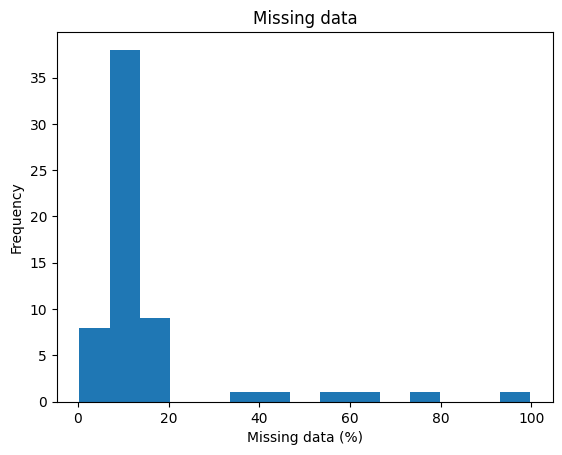

```python
# Create a histogram to show distribution of missing data by percent
ax = azdias_missing_data['percent_missing'].plot(kind='hist',
                                             bins=15,
                                             title='Missing data')
ax.set_xlabel('Missing data (%)');
```

Based on this histogram most of the columns with missing data have less than 20% missing data. Therefore, I will be removing columns that have more than 20% of missing data.

```python
# Create array to store the column names to drop from azdias
cols_to_drop = []

for index in azdias_missing_data.index:
    # Find the rows where percent_missing missing is greater than 20%
    if azdias_missing_data.loc[index]['percent_missing'] > 20:
        # Add the value from the col_name to the array
        cols_to_drop.append(azdias_missing_data.loc[index]['col_name'])

# Check on column names in array
print(f'{len(cols_to_drop)} columns to remove\n {cols_to_drop}')
```

```
6 columns to remove
 ['AGER_TYP', 'GEBURTSJAHR', 'TITEL_KZ', 'ALTER_HH', 'KK_KUNDENTYP', 'KBA05_BAUMAX']
```

```python
# Drop outlier columns from dataset
azdias = azdias.drop((col for col in cols_to_drop), axis=1)

# Confirm columns have been removed
print(azdias.shape)
azdias.head()
```

```
(891221, 79)
```

|  | ALTERSKATEGORIE_GROB | ANREDE_KZ | CJT_GESAMTTYP | FINANZ_MINIMALIST | FINANZ_SPARER | FINANZ_VORSORGER | FINANZ_ANLEGER | FINANZ_UNAUFFAELLIGER | FINANZ_HAUSBAUER | FINANZTYP | GFK_URLAUBERTYP | GREEN_AVANTGARDE | HEALTH_TYP | LP_LEBENSPHASE_FEIN | LP_LEBENSPHASE_GROB | LP_FAMILIE_FEIN | LP_FAMILIE_GROB | LP_STATUS_FEIN | LP_STATUS_GROB | NATIONALITAET_KZ | PRAEGENDE_JUGENDJAHRE | RETOURTYP_BK_S | SEMIO_SOZ | SEMIO_FAM | SEMIO_REL | SEMIO_MAT | SEMIO_VERT | SEMIO_LUST | SEMIO_ERL | … |
| --- | --- | --- | --- | --- | --- | --- | --- | --- | --- | --- | --- | --- | --- | --- | --- | --- | --- | --- | --- | --- | --- | --- | --- | --- | --- | --- | --- | --- | --- | --- |
| 0 | 2.0 | 1 | 2.0 | 3 | 4 | 3 | 5 | 5 | 3 | 4 | 10.0 | 0 | NaN | 15.0 | 4.0 | 2.0 | 2.0 | 1.0 | 1.0 | NaN | NaN | 5.0 | 2 | 6 | 7 | 5 | 1 | 5 | 3 | … |
| 1 | 1.0 | 2 | 5.0 | 1 | 5 | 2 | 5 | 4 | 5 | 1 | 10.0 | 0 | 3.0 | 21.0 | 6.0 | 5.0 | 3.0 | 2.0 | 1.0 | 1.0 | 14.0 | 1.0 | 5 | 4 | 4 | 3 | 1 | 2 | 2 | … |
| 2 | 3.0 | 2 | 3.0 | 1 | 4 | 1 | 2 | 3 | 5 | 1 | 10.0 | 1 | 3.0 | 3.0 | 1.0 | 1.0 | 1.0 | 3.0 | 2.0 | 1.0 | 15.0 | 3.0 | 4 | 1 | 3 | 3 | 4 | 4 | 6 | … |
| 3 | 4.0 | 2 | 2.0 | 4 | 2 | 5 | 2 | 1 | 2 | 6 | 1.0 | 0 | 2.0 | NaN | NaN | NaN | NaN | 9.0 | 4.0 | 1.0 | 8.0 | 2.0 | 5 | 1 | 2 | 1 | 4 | 4 | 7 | … |
| 4 | 3.0 | 1 | 5.0 | 4 | 3 | 4 | 1 | 3 | 2 | 5 | 5.0 | 0 | 3.0 | 32.0 | 10.0 | 10.0 | 5.0 | 3.0 | 2.0 | 1.0 | 8.0 | 5.0 | 6 | 4 | 4 | 2 | 7 | 4 | 4 | … |

#### Discussion 1.1.2: Assess Missing Data in Each Column

There were 61 columns with missing data. The average percent of data missing in these columns was 15.40%. Most of the columns with missing data had less than 20% of missing data.

The following six columns were deemed outliers and removed from the dataset:

- `TITEL_KZ` (99.76% missing data)
- `AGER_TYP` (76.96% missing data)
- `KK_KUNDENTYP` (65.60% missing data)
- `KBA05_BAUMAX` (53.47% missing data)
- `GEBURTSJAHR` (44.02% missing data)
- `ALTER_HH` (34.81% missing data)

#### Step 1.1.3: Assess Missing Data in Each Row

Now, you'll perform a similar assessment for the rows of the dataset. How much data is missing in each row? As with the columns, you should see some groups of points that have a very different numbers of missing values. Divide the data into two subsets: one for data points that are above some threshold for missing values, and a second subset for points below that threshold.

In order to know what to do with the outlier rows, we should see if the distribution of data values on columns that are not missing data (or are missing very little data) are similar or different between the two groups. Select at least five of these columns and compare the distribution of values.

- You can use seaborn's [`countplot()`](https://seaborn.pydata.org/generated/seaborn.countplot.html) function to create a bar chart of code frequencies and matplotlib's [`subplot()`](https://matplotlib.org/api/_as_gen/matplotlib.pyplot.subplot.html) function to put bar charts for the two subplots side by side.
- To reduce repeated code, you might want to write a function that can perform this comparison, taking as one of its arguments a column to be compared.

Depending on what you observe in your comparison, this will have implications on how you approach your conclusions later in the analysis. If the distributions of non-missing features look similar between the data with many missing values and the data with few or no missing values, then we could argue that simply dropping those points from the analysis won't present a major issue. On the other hand, if the data with many missing values looks very different from the data with few or no missing values, then we should make a note on those data as special. We'll revisit these data later on. **Either way, you should continue your analysis for now using just the subset of the data with few or no missing values.**

```python
# Keep number of columns for calculating percent missing later
num_cols = azdias.shape[1]

# Get a total of missing values from rows by using sum(axis=1)
# Return the values as a list
amt_missing_in_row = azdias.isna().sum(axis=1).tolist()

# Calculate the percentage of missing values in each row
# Get the total number of missing values and divide by number of columns
# Return the values as a list
percent_missing_in_row = round((azdias.isna().sum(axis=1) / num_cols) * 100, 2).tolist()
```

```python
# Put print statements in separate block due to timeout issues
# Getting slice to avoid showing all records
print(amt_missing_in_row[:10])
print(percent_missing_in_row[:10])
```

```
[43, 0, 0, 7, 0, 0, 0, 0, 0, 0]
[54.43, 0.0, 0.0, 8.86, 0.0, 0.0, 0.0, 0.0, 0.0, 0.0]
```

```python
# Create columns for the total missing and percent missing in the rows
# Store the values for each row in the new columns
azdias['amt_missing_in_row'] = amt_missing_in_row
azdias['percent_missing_in_row'] = percent_missing_in_row
```

```python
# Check that the columns were created and the values are there
azdias.head()
```

|  | ALTERSKATEGORIE_GROB | ANREDE_KZ | CJT_GESAMTTYP | FINANZ_MINIMALIST | FINANZ_SPARER | FINANZ_VORSORGER | FINANZ_ANLEGER | FINANZ_UNAUFFAELLIGER | FINANZ_HAUSBAUER | FINANZTYP | GFK_URLAUBERTYP | GREEN_AVANTGARDE | HEALTH_TYP | LP_LEBENSPHASE_FEIN | LP_LEBENSPHASE_GROB | LP_FAMILIE_FEIN | LP_FAMILIE_GROB | LP_STATUS_FEIN | LP_STATUS_GROB | NATIONALITAET_KZ | PRAEGENDE_JUGENDJAHRE | RETOURTYP_BK_S | SEMIO_SOZ | SEMIO_FAM | SEMIO_REL | SEMIO_MAT | SEMIO_VERT | SEMIO_LUST | SEMIO_ERL | … |
| --- | --- | --- | --- | --- | --- | --- | --- | --- | --- | --- | --- | --- | --- | --- | --- | --- | --- | --- | --- | --- | --- | --- | --- | --- | --- | --- | --- | --- | --- | --- |
| 0 | 2.0 | 1 | 2.0 | 3 | 4 | 3 | 5 | 5 | 3 | 4 | 10.0 | 0 | NaN | 15.0 | 4.0 | 2.0 | 2.0 | 1.0 | 1.0 | NaN | NaN | 5.0 | 2 | 6 | 7 | 5 | 1 | 5 | 3 | … |
| 1 | 1.0 | 2 | 5.0 | 1 | 5 | 2 | 5 | 4 | 5 | 1 | 10.0 | 0 | 3.0 | 21.0 | 6.0 | 5.0 | 3.0 | 2.0 | 1.0 | 1.0 | 14.0 | 1.0 | 5 | 4 | 4 | 3 | 1 | 2 | 2 | … |
| 2 | 3.0 | 2 | 3.0 | 1 | 4 | 1 | 2 | 3 | 5 | 1 | 10.0 | 1 | 3.0 | 3.0 | 1.0 | 1.0 | 1.0 | 3.0 | 2.0 | 1.0 | 15.0 | 3.0 | 4 | 1 | 3 | 3 | 4 | 4 | 6 | … |
| 3 | 4.0 | 2 | 2.0 | 4 | 2 | 5 | 2 | 1 | 2 | 6 | 1.0 | 0 | 2.0 | NaN | NaN | NaN | NaN | 9.0 | 4.0 | 1.0 | 8.0 | 2.0 | 5 | 1 | 2 | 1 | 4 | 4 | 7 | … |
| 4 | 3.0 | 1 | 5.0 | 4 | 3 | 4 | 1 | 3 | 2 | 5 | 5.0 | 0 | 3.0 | 32.0 | 10.0 | 10.0 | 5.0 | 3.0 | 2.0 | 1.0 | 8.0 | 5.0 | 6 | 4 | 4 | 2 | 7 | 4 | 4 | … |

```python
azdias['amt_missing_in_row'].describe()
```

```
count    891221.000000
mean          5.649894
std          13.234687
min           0.000000
25%           0.000000
50%           0.000000
75%           3.000000
max          49.000000
Name: amt_missing_in_row, dtype: float64
```

```python
azdias['percent_missing_in_row'].describe()
```

```
count    891221.000000
mean          7.151636
std          16.752159
min           0.000000
25%           0.000000
50%           0.000000
75%           3.800000
max          62.030000
Name: percent_missing_in_row, dtype: float64
```

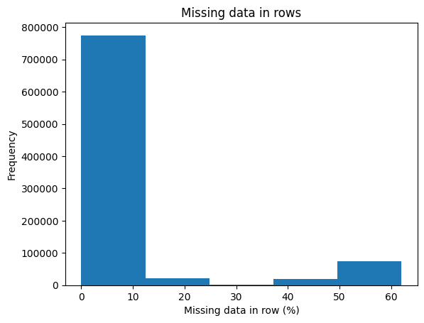

```python
# Create a histogram to show distribution of missing data in rows by percent
ax = azdias['percent_missing_in_row'].plot(kind='hist',
                                             bins=5,
                                             title='Missing data in rows')
ax.set_xlabel('Missing data in row (%)');
```

```python
# Create subset to keep rows that are missing less than 30% of data
azdias_lm = azdias.query('percent_missing_in_row < 30')

# Create subset to keep rows that are missing 30% or more of data
azdias_hm = azdias.query('percent_missing_in_row >= 30')
```

```python
# Get info on subset with less than 30% missing data in the rows
print(azdias_lm.shape)
azdias_lm.head()
```

```
(797837, 81)
```

|  | ALTERSKATEGORIE_GROB | ANREDE_KZ | CJT_GESAMTTYP | FINANZ_MINIMALIST | FINANZ_SPARER | FINANZ_VORSORGER | FINANZ_ANLEGER | FINANZ_UNAUFFAELLIGER | FINANZ_HAUSBAUER | FINANZTYP | GFK_URLAUBERTYP | GREEN_AVANTGARDE | HEALTH_TYP | LP_LEBENSPHASE_FEIN | LP_LEBENSPHASE_GROB | LP_FAMILIE_FEIN | LP_FAMILIE_GROB | LP_STATUS_FEIN | LP_STATUS_GROB | NATIONALITAET_KZ | PRAEGENDE_JUGENDJAHRE | RETOURTYP_BK_S | SEMIO_SOZ | SEMIO_FAM | SEMIO_REL | SEMIO_MAT | SEMIO_VERT | SEMIO_LUST | SEMIO_ERL | … |
| --- | --- | --- | --- | --- | --- | --- | --- | --- | --- | --- | --- | --- | --- | --- | --- | --- | --- | --- | --- | --- | --- | --- | --- | --- | --- | --- | --- | --- | --- | --- |
| 1 | 1.0 | 2 | 5.0 | 1 | 5 | 2 | 5 | 4 | 5 | 1 | 10.0 | 0 | 3.0 | 21.0 | 6.0 | 5.0 | 3.0 | 2.0 | 1.0 | 1.0 | 14.0 | 1.0 | 5 | 4 | 4 | 3 | 1 | 2 | 2 | … |
| 2 | 3.0 | 2 | 3.0 | 1 | 4 | 1 | 2 | 3 | 5 | 1 | 10.0 | 1 | 3.0 | 3.0 | 1.0 | 1.0 | 1.0 | 3.0 | 2.0 | 1.0 | 15.0 | 3.0 | 4 | 1 | 3 | 3 | 4 | 4 | 6 | … |
| 3 | 4.0 | 2 | 2.0 | 4 | 2 | 5 | 2 | 1 | 2 | 6 | 1.0 | 0 | 2.0 | NaN | NaN | NaN | NaN | 9.0 | 4.0 | 1.0 | 8.0 | 2.0 | 5 | 1 | 2 | 1 | 4 | 4 | 7 | … |
| 4 | 3.0 | 1 | 5.0 | 4 | 3 | 4 | 1 | 3 | 2 | 5 | 5.0 | 0 | 3.0 | 32.0 | 10.0 | 10.0 | 5.0 | 3.0 | 2.0 | 1.0 | 8.0 | 5.0 | 6 | 4 | 4 | 2 | 7 | 4 | 4 | … |
| 5 | 1.0 | 2 | 2.0 | 3 | 1 | 5 | 2 | 2 | 5 | 2 | 1.0 | 0 | 3.0 | 8.0 | 2.0 | 1.0 | 1.0 | 4.0 | 2.0 | 1.0 | 3.0 | 3.0 | 2 | 4 | 7 | 4 | 2 | 2 | 2 | … |

```python
# Get info on subset with 30% or more of missing data in the rows
print(azdias_hm.shape)
azdias_hm.head()
```

```
(93384, 81)
```

|  | ALTERSKATEGORIE_GROB | ANREDE_KZ | CJT_GESAMTTYP | FINANZ_MINIMALIST | FINANZ_SPARER | FINANZ_VORSORGER | FINANZ_ANLEGER | FINANZ_UNAUFFAELLIGER | FINANZ_HAUSBAUER | FINANZTYP | GFK_URLAUBERTYP | GREEN_AVANTGARDE | HEALTH_TYP | LP_LEBENSPHASE_FEIN | LP_LEBENSPHASE_GROB | LP_FAMILIE_FEIN | LP_FAMILIE_GROB | LP_STATUS_FEIN | LP_STATUS_GROB | NATIONALITAET_KZ | PRAEGENDE_JUGENDJAHRE | RETOURTYP_BK_S | SEMIO_SOZ | SEMIO_FAM | SEMIO_REL | SEMIO_MAT | SEMIO_VERT | SEMIO_LUST | SEMIO_ERL | … |
| --- | --- | --- | --- | --- | --- | --- | --- | --- | --- | --- | --- | --- | --- | --- | --- | --- | --- | --- | --- | --- | --- | --- | --- | --- | --- | --- | --- | --- | --- | --- |
| 0 | 2.0 | 1 | 2.0 | 3 | 4 | 3 | 5 | 5 | 3 | 4 | 10.0 | 0 | NaN | 15.0 | 4.0 | 2.0 | 2.0 | 1.0 | 1.0 | NaN | NaN | 5.0 | 2 | 6 | 7 | 5 | 1 | 5 | 3 | … |
| 11 | 2.0 | 1 | 6.0 | 3 | 4 | 3 | 5 | 5 | 3 | 4 | 5.0 | 0 | NaN | NaN | NaN | NaN | NaN | 5.0 | 2.0 | NaN | NaN | 3.0 | 2 | 6 | 7 | 5 | 1 | 5 | 3 | … |
| 14 | 3.0 | 1 | 6.0 | 3 | 4 | 3 | 5 | 5 | 3 | 4 | 5.0 | 0 | NaN | NaN | NaN | NaN | NaN | 5.0 | 2.0 | NaN | NaN | 3.0 | 2 | 6 | 7 | 5 | 1 | 5 | 3 | … |
| 17 | 2.0 | 1 | 6.0 | 3 | 4 | 3 | 5 | 5 | 3 | 4 | 5.0 | 0 | NaN | NaN | NaN | NaN | NaN | 5.0 | 2.0 | NaN | NaN | 3.0 | 2 | 6 | 7 | 5 | 1 | 5 | 3 | … |
| 24 | 3.0 | 2 | 6.0 | 3 | 4 | 3 | 5 | 5 | 3 | 4 | 5.0 | 0 | NaN | NaN | NaN | NaN | NaN | 5.0 | 2.0 | NaN | NaN | 3.0 | 2 | 6 | 7 | 5 | 1 | 5 | 3 | … |

```python
# Look for columns where the non-null count equals the number of entries
azdias.info()
```

```
<class 'pandas.core.frame.DataFrame'>
RangeIndex: 891221 entries, 0 to 891220
Data columns (total 81 columns):
 #   Column                  Non-Null Count   Dtype
---  ------                  --------------   -----
 0   ALTERSKATEGORIE_GROB    888340 non-null  float64
 1   ANREDE_KZ               891221 non-null  int64
 2   CJT_GESAMTTYP           886367 non-null  float64
 3   FINANZ_MINIMALIST       891221 non-null  int64
 4   FINANZ_SPARER           891221 non-null  int64
 5   FINANZ_VORSORGER        891221 non-null  int64
 6   FINANZ_ANLEGER          891221 non-null  int64
 7   FINANZ_UNAUFFAELLIGER   891221 non-null  int64
 8   FINANZ_HAUSBAUER        891221 non-null  int64
 9   FINANZTYP               891221 non-null  int64
```

[output cut: 73 more lines]

```python
# Ensure I am getting the correct columns that don't have missing data
print(azdias.columns[3:8])
print(azdias.columns[3:8].isna().any())
```

```
Index(['FINANZ_MINIMALIST', 'FINANZ_SPARER', 'FINANZ_VORSORGER',
       'FINANZ_ANLEGER', 'FINANZ_UNAUFFAELLIGER'],
      dtype='object')
False
```

These are columns that do not have any missing data in the columns

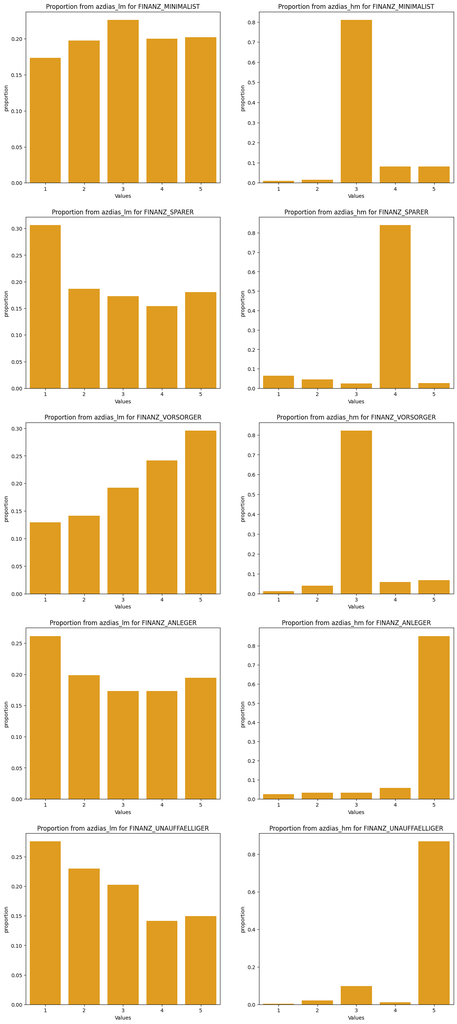

```python
# Compare the distribution of values for at least five columns where there are
# no or few missing values, between the two subsets.

fig, axes = plt.subplots(nrows = 5, ncols = 2, figsize = (15, 35))
n = 0
for col in azdias.columns[3:8]:
    sns.countplot(data=azdias, x=azdias_lm.loc[:, col], ax = axes[n, 0], stat='proportion', color='orange')
    axes[n, 0].set_title(f'Proportion from azdias_lm for {col}')
    axes[n, 0].set_xlabel('Values')
    sns.countplot(data=azdias, x=azdias_hm.loc[:, col], ax = axes[n, 1], stat='proportion', color='orange')
    axes[n, 1].set_title(f'Proportion from azdias_hm for {col}')
    axes[n, 1].set_xlabel('Values')
    n += 1
```

#### Discussion 1.1.3: Assess Missing Data in Each Row

Columns picked to compare between subsets because there were 0 missing values:

- `FINANZ_MINIMALIST`
- `FINANZ_SPARER`
- `FINANZ_VORSORGER`
- `'FINANZ_ANLEGE`
- `'FINANZ_UNAUFFAELLIGE`' On the left side we can see the plots for the dataset where the rows have less than 30% of missing data. On the right side we can see the plots for the dataset where the rows have 30% or more of missing data. Each side-by-side plot is a comparison of the same column and the plot is showing the proportion of the values for their respective dataset.

This shows us that the `azdias_lm` dataset does have different distribution of values than the `azdias_hm` dataset. This means I will continue working with the `azdias_lm` dataset for now since it has less missing data overall. The `azdias_hm` dataset with more missing values will have to be handled later on.)

### Step 1.2: Select and Re-Encode Features

Checking for missing data isn't the only way in which you can prepare a dataset for analysis. Since the unsupervised learning techniques to be used will only work on data that is encoded numerically, you need to make a few encoding changes or additional assumptions to be able to make progress. In addition, while almost all of the values in the dataset are encoded using numbers, not all of them represent numeric values. Check the third column of the feature summary (`feat_info`) for a summary of types of measurement.

- For numeric and interval data, these features can be kept without changes.
- Most of the variables in the dataset are ordinal in nature. While ordinal values may technically be non-linear in spacing, make the simplifying assumption that the ordinal variables can be treated as being interval in nature (that is, kept without any changes).
- Special handling may be necessary for the remaining two variable types: categorical, and 'mixed'.

In the first two parts of this sub-step, you will perform an investigation of the categorical and mixed-type features and make a decision on each of them, whether you will keep, drop, or re-encode each. Then, in the last part, you will create a new data frame with only the selected and engineered columns.

Data wrangling is often the trickiest part of the data analysis process, and there's a lot of it to be done here. But stick with it: once you're done with this step, you'll be ready to get to the machine learning parts of the project!

```python
# How many features are there of each data type?
feat_info['type'].value_counts()
```

```
type
ordinal        49
categorical    21
numeric         7
mixed           7
interval        1
Name: count, dtype: int64
```

#### Step 1.2.1: Re-Encode Categorical Features

For categorical data, you would ordinarily need to encode the levels as dummy variables. Depending on the number of categories, perform one of the following:

- For binary (two-level) categoricals that take numeric values, you can keep them without needing to do anything.
- There is one binary variable that takes on non-numeric values. For this one, you need to re-encode the values as numbers or create a dummy variable.
- For multi-level categoricals (three or more values), you can choose to encode the values using multiple dummy variables (e.g. via [OneHotEncoder](http://scikit-learn.org/stable/modules/generated/sklearn.preprocessing.OneHotEncoder.html)), or (to keep things straightforward) just drop them from the analysis. As always, document your choices in the Discussion section.

```python
# Create array to hold all column names that are categorical
cat_cols = feat_info.query('type == "categorical"').attribute.values.tolist()

binary_cols = []
multilevel_cols =[]

# Check each column name to see if it is in the azdias_lm dataset
for col in cat_cols:
    if col in azdias_lm.columns:
        if azdias_lm[col].nunique() == 2:
            binary_cols.append(col)
        elif azdias_lm[col].nunique() > 2 :
            multilevel_cols.append(col)
        else:
            print(f'This {col} has less than 2 values and could not be added an array.')
    else:
        print(f'The {col} column is not part of the azdias_lm subset and was not added to an array.\n\n')
        continue
    print(f' {col} has {azdias_lm[col].nunique()} unique values. \n Unique values: {azdias_lm[col].sort_values().unique()}\n\n')
```

```
The AGER_TYP column is not part of the azdias_lm subset and was not added to an array.


 ANREDE_KZ has 2 unique values.
 Unique values: [1 2]


 CJT_GESAMTTYP has 6 unique values.
 Unique values: [ 1.  2.  3.  4.  5.  6. nan]


 FINANZTYP has 6 unique values.
 Unique values: [1 2 3 4 5 6]


 GFK_URLAUBERTYP has 12 unique values.
 Unique values: [ 1.  2.  3.  4.  5.  6.  7.  8.  9. 10. 11. 12. nan]


 GREEN_AVANTGARDE has 2 unique values.
 Unique values: [0 1]


 LP_FAMILIE_FEIN has 11 unique values.
 Unique values: [ 1.  2.  3.  4.  5.  6.  7.  8.  9. 10. 11. nan]


 LP_FAMILIE_GROB has 5 unique values.
 Unique values: [ 1.  2.  3.  4.  5. nan]


 LP_STATUS_FEIN has 10 unique values.
 Unique values: [ 1.  2.  3.  4.  5.  6.  7.  8.  9. 10. nan]


 LP_STATUS_GROB has 5 unique values.
 Unique values: [ 1.  2.  3.  4.  5. nan]


 NATIONALITAET_KZ has 3 unique values.
```

[output cut: 27 more lines]

```


 OST_WEST_KZ has 2 unique values.
 Unique values: ['O' 'W']


 CAMEO_DEUG_2015 has 9 unique values.
 Unique values: ['1' '2' '3' '4' '5' '6' '7' '8' '9' nan]


 CAMEO_DEU_2015 has 44 unique values.
 Unique values: ['1A' '1B' '1C' '1D' '1E' '2A' '2B' '2C' '2D' '3A' '3B' '3C' '3D' '4A'
 '4B' '4C' '4D' '4E' '5A' '5B' '5C' '5D' '5E' '5F' '6A' '6B' '6C' '6D'
 '6E' '6F' '7A' '7B' '7C' '7D' '7E' '8A' '8B' '8C' '8D' '9A' '9B' '9C'
 '9D' '9E' nan]
```

```python
print(f'Total number of categorical columns: {len(binary_cols) + len(multilevel_cols)}')
print(f'Total number of binary categorical columns: {len(binary_cols)}')
print(f'Total number of multilevel categorical columns: {len(multilevel_cols)}')
```

```
Total number of categorical columns: 18
Total number of binary categorical columns: 5
Total number of multilevel categorical columns: 13
```

```python
# Find binary cat columns that are non-numeric
for col in binary_cols:
    if azdias_lm[col].dtypes == object:
        print(azdias_lm[col].value_counts())
```

```
OST_WEST_KZ
W    629332
O    168505
Name: count, dtype: int64
```

```python
# Re-encode binary values as integers
# W == 1 and O == 0
azdias_lm['OST_WEST_KZ'] = (azdias_lm['OST_WEST_KZ'] == 'W').astype(int)
```

```python
# Confirm that the columns are changed to integers
print(azdias_lm['OST_WEST_KZ'].value_counts())
```

```
OST_WEST_KZ
1    629332
0    168505
Name: count, dtype: int64
```

```python
# Drop all multilevel columns
azdias_lm_no_mlc = azdias_lm.drop((col for col in multilevel_cols), axis=1)
```

```python
# Check that multilevel columns have been removed
print(f'Number of columns before: {azdias_lm.shape[1]}\n Number of columns after: {azdias_lm_no_mlc.shape[1]}')
print(f'A difference of {azdias_lm.shape[1] - azdias_lm_no_mlc.shape[1]}')
azdias_lm_no_mlc.columns
```

```
Number of columns before: 81
 Number of columns after: 68
A difference of 13
```

```
Index(['ALTERSKATEGORIE_GROB', 'ANREDE_KZ', 'FINANZ_MINIMALIST',
       'FINANZ_SPARER', 'FINANZ_VORSORGER', 'FINANZ_ANLEGER',
       'FINANZ_UNAUFFAELLIGER', 'FINANZ_HAUSBAUER', 'GREEN_AVANTGARDE',
       'HEALTH_TYP', 'LP_LEBENSPHASE_FEIN', 'LP_LEBENSPHASE_GROB',
       'PRAEGENDE_JUGENDJAHRE', 'RETOURTYP_BK_S', 'SEMIO_SOZ', 'SEMIO_FAM',
       'SEMIO_REL', 'SEMIO_MAT', 'SEMIO_VERT', 'SEMIO_LUST', 'SEMIO_ERL',
       'SEMIO_KULT', 'SEMIO_RAT', 'SEMIO_KRIT', 'SEMIO_DOM', 'SEMIO_KAEM',
       'SEMIO_PFLICHT', 'SEMIO_TRADV', 'SOHO_KZ', 'VERS_TYP', 'ANZ_PERSONEN',
       'ANZ_TITEL', 'HH_EINKOMMEN_SCORE', 'W_KEIT_KIND_HH', 'WOHNDAUER_2008',
       'ANZ_HAUSHALTE_AKTIV', 'ANZ_HH_TITEL', 'KONSUMNAEHE',
       'MIN_GEBAEUDEJAHR', 'OST_WEST_KZ', 'WOHNLAGE', 'CAMEO_INTL_2015',
       'KBA05_ANTG1', 'KBA05_ANTG2', 'KBA05_ANTG3', 'KBA05_ANTG4', 'KBA05_GBZ',
       'BALLRAUM', 'EWDICHTE', 'INNENSTADT', 'GEBAEUDETYP_RASTER', 'KKK',
       'MOBI_REGIO', 'ONLINE_AFFINITAET', 'REGIOTYP', 'KBA13_ANZAHL_PKW',
       'PLZ8_ANTG1', 'PLZ8_ANTG2', 'PLZ8_ANTG3', 'PLZ8_ANTG4', 'PLZ8_BAUMAX',
       'PLZ8_HHZ', 'PLZ8_GBZ', 'ARBEIT', 'ORTSGR_KLS9', 'RELAT_AB',
       'amt_missing_in_row', 'percent_missing_in_row'],
      dtype='object')
```

#### Discussion 1.2.1: Re-Encode Categorical Features

All 13 of the columns that were of the multilevel type was removed to keep the analysis straightforward. Future analysis may require to add this columns back to get a deeper understanding of relationships in the data.

The `OST_WEST_KZ` was binary but not as a numeric type so I changed this so that the W is represented as a 1 and the O is represented as a 0.

#### Step 1.2.2: Engineer Mixed-Type Features

There are a handful of features that are marked as "mixed" in the feature summary that require special treatment in order to be included in the analysis. There are two in particular that deserve attention; the handling of the rest are up to your own choices:

- "PRAEGENDE_JUGENDJAHRE" combines information on three dimensions: generation by decade, movement (mainstream vs. avantgarde), and nation (east vs. west). While there aren't enough levels to disentangle east from west, you should create two new variables to capture the other two dimensions: an interval-type variable for decade, and a binary variable for movement.
- "CAMEO_INTL_2015" combines information on two axes: wealth and life stage. Break up the two-digit codes by their 'tens'-place and 'ones'-place digits into two new ordinal variables (which, for the purposes of this project, is equivalent to just treating them as their raw numeric values).
- If you decide to keep or engineer new features around the other mixed-type features, make sure you note your steps in the Discussion section.

Be sure to check `Data_Dictionary.md` for the details needed to finish these tasks.

```python
# Investigate "PRAEGENDE_JUGENDJAHRE" and engineer two new variables.
"""
Dominating movement of person's youth (avantgarde vs. mainstream; east vs. west)
-  1: 40s - war years (Mainstream, E+W)
-  2: 40s - reconstruction years (Avantgarde, E+W)
-  3: 50s - economic miracle (Mainstream, E+W)
-  4: 50s - milk bar / Individualisation (Avantgarde, E+W)
-  5: 60s - economic miracle (Mainstream, E+W)
-  6: 60s - generation 68 / student protestors (Avantgarde, W)
-  7: 60s - opponents to the building of the Wall (Avantgarde, E)
-  8: 70s - family orientation (Mainstream, E+W)
-  9: 70s - peace movement (Avantgarde, E+W)
- 10: 80s - Generation Golf (Mainstream, W)
- 11: 80s - ecological awareness (Avantgarde, W)
- 12: 80s - FDJ / communist party youth organisation (Mainstream, E)
- 13: 80s - Swords into ploughshares (Avantgarde, E)
- 14: 90s - digital media kids (Mainstream, E+W)
- 15: 90s - ecological awareness (Avantgarde, E+W)
"""

# Create dict for decade
decade = {1:4, 2:4, 3:5, 4:5, 5:6, 6:6, 7:6, 8:7, 9:7, 10:8, 11:8, 12:8, 13:8, 14:9, 15:9}

# Create dict for movement
# Mainstream == 1 and Avantgarde == 0
movement = {1:1, 2:0, 3:1, 4:0, 5:1, 6:0, 7:0, 8:1, 9:0, 10:1, 11:0, 12:1, 13:0, 14:1, 15:0}

# Create new columns
azdias_lm_no_mlc['PRAEGENDE_JUGENDJAHRE_DECADE'] = azdias_lm_no_mlc['PRAEGENDE_JUGENDJAHRE']
azdias_lm_no_mlc['PRAEGENDE_JUGENDJAHRE_MOVEMENT'] = azdias_lm_no_mlc['PRAEGENDE_JUGENDJAHRE']

azdias_lm_no_mlc['PRAEGENDE_JUGENDJAHRE_DECADE'] = azdias_lm_no_mlc['PRAEGENDE_JUGENDJAHRE_DECADE'].replace(decade)
azdias_lm_no_mlc['PRAEGENDE_JUGENDJAHRE_MOVEMENT'] = azdias_lm_no_mlc['PRAEGENDE_JUGENDJAHRE_MOVEMENT'].replace(movement)
```

```python
# Check for new columns and values
azdias_lm_no_mlc.head()
```

|  | ALTERSKATEGORIE_GROB | ANREDE_KZ | FINANZ_MINIMALIST | FINANZ_SPARER | FINANZ_VORSORGER | FINANZ_ANLEGER | FINANZ_UNAUFFAELLIGER | FINANZ_HAUSBAUER | GREEN_AVANTGARDE | HEALTH_TYP | LP_LEBENSPHASE_FEIN | LP_LEBENSPHASE_GROB | PRAEGENDE_JUGENDJAHRE | RETOURTYP_BK_S | SEMIO_SOZ | SEMIO_FAM | SEMIO_REL | SEMIO_MAT | SEMIO_VERT | SEMIO_LUST | SEMIO_ERL | SEMIO_KULT | SEMIO_RAT | SEMIO_KRIT | SEMIO_DOM | SEMIO_KAEM | SEMIO_PFLICHT | SEMIO_TRADV | SOHO_KZ | … |
| --- | --- | --- | --- | --- | --- | --- | --- | --- | --- | --- | --- | --- | --- | --- | --- | --- | --- | --- | --- | --- | --- | --- | --- | --- | --- | --- | --- | --- | --- | --- |
| 1 | 1.0 | 2 | 1 | 5 | 2 | 5 | 4 | 5 | 0 | 3.0 | 21.0 | 6.0 | 14.0 | 1.0 | 5 | 4 | 4 | 3 | 1 | 2 | 2 | 3 | 6 | 4 | 7 | 4 | 7 | 6 | 1.0 | … |
| 2 | 3.0 | 2 | 1 | 4 | 1 | 2 | 3 | 5 | 1 | 3.0 | 3.0 | 1.0 | 15.0 | 3.0 | 4 | 1 | 3 | 3 | 4 | 4 | 6 | 3 | 4 | 7 | 7 | 7 | 3 | 3 | 0.0 | … |
| 3 | 4.0 | 2 | 4 | 2 | 5 | 2 | 1 | 2 | 0 | 2.0 | NaN | NaN | 8.0 | 2.0 | 5 | 1 | 2 | 1 | 4 | 4 | 7 | 4 | 3 | 4 | 4 | 5 | 4 | 4 | 0.0 | … |
| 4 | 3.0 | 1 | 4 | 3 | 4 | 1 | 3 | 2 | 0 | 3.0 | 32.0 | 10.0 | 8.0 | 5.0 | 6 | 4 | 4 | 2 | 7 | 4 | 4 | 6 | 2 | 3 | 2 | 2 | 4 | 2 | 0.0 | … |
| 5 | 1.0 | 2 | 3 | 1 | 5 | 2 | 2 | 5 | 0 | 3.0 | 8.0 | 2.0 | 3.0 | 3.0 | 2 | 4 | 7 | 4 | 2 | 2 | 2 | 5 | 7 | 4 | 4 | 4 | 7 | 6 | 0.0 | … |

```python
# Drop PRAEGENDE_JUGENDJAHRE column from dataset
azdias_lm_no_mlc = azdias_lm_no_mlc.drop('PRAEGENDE_JUGENDJAHRE', axis=1)
```

```python
# Check that column was removed
azdias_lm_no_mlc.columns
```

```
Index(['ALTERSKATEGORIE_GROB', 'ANREDE_KZ', 'FINANZ_MINIMALIST',
       'FINANZ_SPARER', 'FINANZ_VORSORGER', 'FINANZ_ANLEGER',
       'FINANZ_UNAUFFAELLIGER', 'FINANZ_HAUSBAUER', 'GREEN_AVANTGARDE',
       'HEALTH_TYP', 'LP_LEBENSPHASE_FEIN', 'LP_LEBENSPHASE_GROB',
       'RETOURTYP_BK_S', 'SEMIO_SOZ', 'SEMIO_FAM', 'SEMIO_REL', 'SEMIO_MAT',
       'SEMIO_VERT', 'SEMIO_LUST', 'SEMIO_ERL', 'SEMIO_KULT', 'SEMIO_RAT',
       'SEMIO_KRIT', 'SEMIO_DOM', 'SEMIO_KAEM', 'SEMIO_PFLICHT', 'SEMIO_TRADV',
       'SOHO_KZ', 'VERS_TYP', 'ANZ_PERSONEN', 'ANZ_TITEL',
       'HH_EINKOMMEN_SCORE', 'W_KEIT_KIND_HH', 'WOHNDAUER_2008',
       'ANZ_HAUSHALTE_AKTIV', 'ANZ_HH_TITEL', 'KONSUMNAEHE',
       'MIN_GEBAEUDEJAHR', 'OST_WEST_KZ', 'WOHNLAGE', 'CAMEO_INTL_2015',
       'KBA05_ANTG1', 'KBA05_ANTG2', 'KBA05_ANTG3', 'KBA05_ANTG4', 'KBA05_GBZ',
       'BALLRAUM', 'EWDICHTE', 'INNENSTADT', 'GEBAEUDETYP_RASTER', 'KKK',
       'MOBI_REGIO', 'ONLINE_AFFINITAET', 'REGIOTYP', 'KBA13_ANZAHL_PKW',
       'PLZ8_ANTG1', 'PLZ8_ANTG2', 'PLZ8_ANTG3', 'PLZ8_ANTG4', 'PLZ8_BAUMAX',
       'PLZ8_HHZ', 'PLZ8_GBZ', 'ARBEIT', 'ORTSGR_KLS9', 'RELAT_AB',
       'amt_missing_in_row', 'percent_missing_in_row',
       'PRAEGENDE_JUGENDJAHRE_DECADE', 'PRAEGENDE_JUGENDJAHRE_MOVEMENT'],
      dtype='object')
```

```python
# Investigate "CAMEO_INTL_2015" and engineer two new variables.
"""
- 11: Wealthy Households - Pre-Family Couples & Singles
- 12: Wealthy Households - Young Couples With Children
- 13: Wealthy Households - Families With School Age Children
- 14: Wealthy Households - Older Families &  Mature Couples
- 15: Wealthy Households - Elders In Retirement
- 21: Prosperous Households - Pre-Family Couples & Singles
- 22: Prosperous Households - Young Couples With Children
- 23: Prosperous Households - Families With School Age Children
- 24: Prosperous Households - Older Families & Mature Couples
- 25: Prosperous Households - Elders In Retirement
- 31: Comfortable Households - Pre-Family Couples & Singles
- 32: Comfortable Households - Young Couples With Children
- 33: Comfortable Households - Families With School Age Children
- 34: Comfortable Households - Older Families & Mature Couples
- 35: Comfortable Households - Elders In Retirement
- 41: Less Affluent Households - Pre-Family Couples & Singles
- 42: Less Affluent Households - Young Couples With Children
- 43: Less Affluent Households - Families With School Age Children
- 44: Less Affluent Households - Older Families & Mature Couples
- 45: Less Affluent Households - Elders In Retirement
- 51: Poorer Households - Pre-Family Couples & Singles
- 52: Poorer Households - Young Couples With Children
- 53: Poorer Households - Families With School Age Children
- 54: Poorer Households - Older Families & Mature Couples
- 55: Poorer Households - Elders In Retirement
"""

# Create dict for wealth
# The tens digit will be used for wealth level
wealth = {"11":1, "12":1, "13":1, "14":1, "15":1, "21":2, "22":2, "23":2,
          "24":2, "25":2, "31":3, "32":3, "33":3, "34":3, "35":3, "41":4,
          "42":4, "43":4, "44":4, "45":4, "51":5, "52":5, "53":5, "54":5, "55":5}

# Create dict for life_stage
# The ones digit will be used for life_stage
life_stage = {"11":1, "12":2, "13":3, "14":4, "15":5, "21":1, "22":2, "23":3,
              "24":4, "25":5, "31":1, "32":2, "33":3, "34":4, "35":5, "41":1,
              "42":2, "43":3, "44":4, "45":5, "51":1, "52":2, "53":3, "54":4, "55":5}

# Create new columns
azdias_lm_no_mlc['CAMEO_INTL_2015_WEALTH'] = azdias_lm_no_mlc['CAMEO_INTL_2015']
azdias_lm_no_mlc['CAMEO_INTL_2015_LIFE_STAGE'] = azdias_lm_no_mlc['CAMEO_INTL_2015']

azdias_lm_no_mlc['CAMEO_INTL_2015_WEALTH'] = azdias_lm_no_mlc['CAMEO_INTL_2015_WEALTH'].replace(wealth)
azdias_lm_no_mlc['CAMEO_INTL_2015_LIFE_STAGE'] = azdias_lm_no_mlc['CAMEO_INTL_2015_LIFE_STAGE'].replace(life_stage)
```

```python
# Check for new columns and values
azdias_lm_no_mlc.head()
```

|  | ALTERSKATEGORIE_GROB | ANREDE_KZ | FINANZ_MINIMALIST | FINANZ_SPARER | FINANZ_VORSORGER | FINANZ_ANLEGER | FINANZ_UNAUFFAELLIGER | FINANZ_HAUSBAUER | GREEN_AVANTGARDE | HEALTH_TYP | LP_LEBENSPHASE_FEIN | LP_LEBENSPHASE_GROB | RETOURTYP_BK_S | SEMIO_SOZ | SEMIO_FAM | SEMIO_REL | SEMIO_MAT | SEMIO_VERT | SEMIO_LUST | SEMIO_ERL | SEMIO_KULT | SEMIO_RAT | SEMIO_KRIT | SEMIO_DOM | SEMIO_KAEM | SEMIO_PFLICHT | SEMIO_TRADV | SOHO_KZ | VERS_TYP | … |
| --- | --- | --- | --- | --- | --- | --- | --- | --- | --- | --- | --- | --- | --- | --- | --- | --- | --- | --- | --- | --- | --- | --- | --- | --- | --- | --- | --- | --- | --- | --- |
| 1 | 1.0 | 2 | 1 | 5 | 2 | 5 | 4 | 5 | 0 | 3.0 | 21.0 | 6.0 | 1.0 | 5 | 4 | 4 | 3 | 1 | 2 | 2 | 3 | 6 | 4 | 7 | 4 | 7 | 6 | 1.0 | 2.0 | … |
| 2 | 3.0 | 2 | 1 | 4 | 1 | 2 | 3 | 5 | 1 | 3.0 | 3.0 | 1.0 | 3.0 | 4 | 1 | 3 | 3 | 4 | 4 | 6 | 3 | 4 | 7 | 7 | 7 | 3 | 3 | 0.0 | 1.0 | … |
| 3 | 4.0 | 2 | 4 | 2 | 5 | 2 | 1 | 2 | 0 | 2.0 | NaN | NaN | 2.0 | 5 | 1 | 2 | 1 | 4 | 4 | 7 | 4 | 3 | 4 | 4 | 5 | 4 | 4 | 0.0 | 1.0 | … |
| 4 | 3.0 | 1 | 4 | 3 | 4 | 1 | 3 | 2 | 0 | 3.0 | 32.0 | 10.0 | 5.0 | 6 | 4 | 4 | 2 | 7 | 4 | 4 | 6 | 2 | 3 | 2 | 2 | 4 | 2 | 0.0 | 2.0 | … |
| 5 | 1.0 | 2 | 3 | 1 | 5 | 2 | 2 | 5 | 0 | 3.0 | 8.0 | 2.0 | 3.0 | 2 | 4 | 7 | 4 | 2 | 2 | 2 | 5 | 7 | 4 | 4 | 4 | 7 | 6 | 0.0 | 2.0 | … |

```python
# Drop CAMEO_INTL_2015 column from dataset
azdias_lm_no_mlc = azdias_lm_no_mlc.drop('CAMEO_INTL_2015', axis=1)
```

```python
# Check that column was removed
azdias_lm_no_mlc.columns
```

```
Index(['ALTERSKATEGORIE_GROB', 'ANREDE_KZ', 'FINANZ_MINIMALIST',
       'FINANZ_SPARER', 'FINANZ_VORSORGER', 'FINANZ_ANLEGER',
       'FINANZ_UNAUFFAELLIGER', 'FINANZ_HAUSBAUER', 'GREEN_AVANTGARDE',
       'HEALTH_TYP', 'LP_LEBENSPHASE_FEIN', 'LP_LEBENSPHASE_GROB',
       'RETOURTYP_BK_S', 'SEMIO_SOZ', 'SEMIO_FAM', 'SEMIO_REL', 'SEMIO_MAT',
       'SEMIO_VERT', 'SEMIO_LUST', 'SEMIO_ERL', 'SEMIO_KULT', 'SEMIO_RAT',
       'SEMIO_KRIT', 'SEMIO_DOM', 'SEMIO_KAEM', 'SEMIO_PFLICHT', 'SEMIO_TRADV',
       'SOHO_KZ', 'VERS_TYP', 'ANZ_PERSONEN', 'ANZ_TITEL',
       'HH_EINKOMMEN_SCORE', 'W_KEIT_KIND_HH', 'WOHNDAUER_2008',
       'ANZ_HAUSHALTE_AKTIV', 'ANZ_HH_TITEL', 'KONSUMNAEHE',
       'MIN_GEBAEUDEJAHR', 'OST_WEST_KZ', 'WOHNLAGE', 'KBA05_ANTG1',
       'KBA05_ANTG2', 'KBA05_ANTG3', 'KBA05_ANTG4', 'KBA05_GBZ', 'BALLRAUM',
       'EWDICHTE', 'INNENSTADT', 'GEBAEUDETYP_RASTER', 'KKK', 'MOBI_REGIO',
       'ONLINE_AFFINITAET', 'REGIOTYP', 'KBA13_ANZAHL_PKW', 'PLZ8_ANTG1',
       'PLZ8_ANTG2', 'PLZ8_ANTG3', 'PLZ8_ANTG4', 'PLZ8_BAUMAX', 'PLZ8_HHZ',
       'PLZ8_GBZ', 'ARBEIT', 'ORTSGR_KLS9', 'RELAT_AB', 'amt_missing_in_row',
       'percent_missing_in_row', 'PRAEGENDE_JUGENDJAHRE_DECADE',
       'PRAEGENDE_JUGENDJAHRE_MOVEMENT', 'CAMEO_INTL_2015_WEALTH',
       'CAMEO_INTL_2015_LIFE_STAGE'],
      dtype='object')
```

```python
# Check on other columns that were mixed
feat_info.query('type == "mixed"')
```

|  | attribute | information_level | type | missing_or_unknown |
| --- | --- | --- | --- | --- |
| 15 | LP_LEBENSPHASE_FEIN | person | mixed | [0] |
| 16 | LP_LEBENSPHASE_GROB | person | mixed | [0] |
| 22 | PRAEGENDE_JUGENDJAHRE | person | mixed | [-1, 0] |
| 56 | WOHNLAGE | building | mixed | [-1] |
| 59 | CAMEO_INTL_2015 | microcell_rr4 | mixed | [-1, XX] |
| 64 | KBA05_BAUMAX | microcell_rr3 | mixed | [-1, 0] |
| 79 | PLZ8_BAUMAX | macrocell_plz8 | mixed | [-1, 0] |

```python
print(azdias_lm_no_mlc['WOHNLAGE'].sort_values().unique())
print(azdias_lm_no_mlc['PLZ8_BAUMAX'].sort_values().unique())
```

```
[0. 1. 2. 3. 4. 5. 7. 8.]
[ 1.  2.  3.  4.  5. nan]
```

Columns to drop: LP_LEBENSPHASE_FEIN - Life stage, fine scale. Already covered by other columns. LP_LEBENSPHASE_GROB - Life stage column, removing since it is also duplicated data WOHNLAGE - Neighborhood quality

Columns can't drop: KBA05_BAUMAX - Already removed because too much missing data was in this column

```python
# Drop LP_LEBENSPHASE_FEIN and LP_LEBENSPHASE_GROB and WOHNLAGE columns from dataset
azdias_lm_no_mlc = azdias_lm_no_mlc.drop(['LP_LEBENSPHASE_FEIN', 'LP_LEBENSPHASE_GROB', 'WOHNLAGE'], axis=1)
```

```python
# Check that columns were removed
azdias_lm_no_mlc.columns
```

```
Index(['ALTERSKATEGORIE_GROB', 'ANREDE_KZ', 'FINANZ_MINIMALIST',
       'FINANZ_SPARER', 'FINANZ_VORSORGER', 'FINANZ_ANLEGER',
       'FINANZ_UNAUFFAELLIGER', 'FINANZ_HAUSBAUER', 'GREEN_AVANTGARDE',
       'HEALTH_TYP', 'RETOURTYP_BK_S', 'SEMIO_SOZ', 'SEMIO_FAM', 'SEMIO_REL',
       'SEMIO_MAT', 'SEMIO_VERT', 'SEMIO_LUST', 'SEMIO_ERL', 'SEMIO_KULT',
       'SEMIO_RAT', 'SEMIO_KRIT', 'SEMIO_DOM', 'SEMIO_KAEM', 'SEMIO_PFLICHT',
       'SEMIO_TRADV', 'SOHO_KZ', 'VERS_TYP', 'ANZ_PERSONEN', 'ANZ_TITEL',
       'HH_EINKOMMEN_SCORE', 'W_KEIT_KIND_HH', 'WOHNDAUER_2008',
       'ANZ_HAUSHALTE_AKTIV', 'ANZ_HH_TITEL', 'KONSUMNAEHE',
       'MIN_GEBAEUDEJAHR', 'OST_WEST_KZ', 'KBA05_ANTG1', 'KBA05_ANTG2',
       'KBA05_ANTG3', 'KBA05_ANTG4', 'KBA05_GBZ', 'BALLRAUM', 'EWDICHTE',
       'INNENSTADT', 'GEBAEUDETYP_RASTER', 'KKK', 'MOBI_REGIO',
       'ONLINE_AFFINITAET', 'REGIOTYP', 'KBA13_ANZAHL_PKW', 'PLZ8_ANTG1',
       'PLZ8_ANTG2', 'PLZ8_ANTG3', 'PLZ8_ANTG4', 'PLZ8_BAUMAX', 'PLZ8_HHZ',
       'PLZ8_GBZ', 'ARBEIT', 'ORTSGR_KLS9', 'RELAT_AB', 'amt_missing_in_row',
       'percent_missing_in_row', 'PRAEGENDE_JUGENDJAHRE_DECADE',
       'PRAEGENDE_JUGENDJAHRE_MOVEMENT', 'CAMEO_INTL_2015_WEALTH',
       'CAMEO_INTL_2015_LIFE_STAGE'],
      dtype='object')
```

```python
# Investigate "PLZ8_BAUMAX" and engineer boolean variable.
"""
-  1: mainly 1-2 family homes
-  2: mainly 3-5 family homes
-  3: mainly 6-10 family homes
-  4: mainly 10+ family homes
-  5: mainly business buildings
"""

# Create dict for mainly family or business building
# Mainly family homes == 1 and Mainly business buildings == 0
family_home = {1:1, 2:1, 3:1, 4:1, 5:0}

# Create new columns
azdias_lm_no_mlc['PLZ8_BAUMAX_FAMILY_HOME'] = azdias_lm_no_mlc['PLZ8_BAUMAX']

azdias_lm_no_mlc['PLZ8_BAUMAX_FAMILY_HOME'] = azdias_lm_no_mlc['PLZ8_BAUMAX_FAMILY_HOME'].replace(family_home)
```

```python
# Check for new columns and values
azdias_lm_no_mlc.head()
```

|  | ALTERSKATEGORIE_GROB | ANREDE_KZ | FINANZ_MINIMALIST | FINANZ_SPARER | FINANZ_VORSORGER | FINANZ_ANLEGER | FINANZ_UNAUFFAELLIGER | FINANZ_HAUSBAUER | GREEN_AVANTGARDE | HEALTH_TYP | RETOURTYP_BK_S | SEMIO_SOZ | SEMIO_FAM | SEMIO_REL | SEMIO_MAT | SEMIO_VERT | SEMIO_LUST | SEMIO_ERL | SEMIO_KULT | SEMIO_RAT | SEMIO_KRIT | SEMIO_DOM | SEMIO_KAEM | SEMIO_PFLICHT | SEMIO_TRADV | SOHO_KZ | VERS_TYP | ANZ_PERSONEN | ANZ_TITEL | … |
| --- | --- | --- | --- | --- | --- | --- | --- | --- | --- | --- | --- | --- | --- | --- | --- | --- | --- | --- | --- | --- | --- | --- | --- | --- | --- | --- | --- | --- | --- | --- |
| 1 | 1.0 | 2 | 1 | 5 | 2 | 5 | 4 | 5 | 0 | 3.0 | 1.0 | 5 | 4 | 4 | 3 | 1 | 2 | 2 | 3 | 6 | 4 | 7 | 4 | 7 | 6 | 1.0 | 2.0 | 2.0 | 0.0 | … |
| 2 | 3.0 | 2 | 1 | 4 | 1 | 2 | 3 | 5 | 1 | 3.0 | 3.0 | 4 | 1 | 3 | 3 | 4 | 4 | 6 | 3 | 4 | 7 | 7 | 7 | 3 | 3 | 0.0 | 1.0 | 1.0 | 0.0 | … |
| 3 | 4.0 | 2 | 4 | 2 | 5 | 2 | 1 | 2 | 0 | 2.0 | 2.0 | 5 | 1 | 2 | 1 | 4 | 4 | 7 | 4 | 3 | 4 | 4 | 5 | 4 | 4 | 0.0 | 1.0 | 0.0 | 0.0 | … |
| 4 | 3.0 | 1 | 4 | 3 | 4 | 1 | 3 | 2 | 0 | 3.0 | 5.0 | 6 | 4 | 4 | 2 | 7 | 4 | 4 | 6 | 2 | 3 | 2 | 2 | 4 | 2 | 0.0 | 2.0 | 4.0 | 0.0 | … |
| 5 | 1.0 | 2 | 3 | 1 | 5 | 2 | 2 | 5 | 0 | 3.0 | 3.0 | 2 | 4 | 7 | 4 | 2 | 2 | 2 | 5 | 7 | 4 | 4 | 4 | 7 | 6 | 0.0 | 2.0 | 1.0 | 0.0 | … |

```python
# Drop PLZ8_BAUMAX column from dataset
azdias_lm_no_mlc = azdias_lm_no_mlc.drop('PLZ8_BAUMAX', axis=1)
```

```python
# Check that column was removed
azdias_lm_no_mlc.columns
```

```
Index(['ALTERSKATEGORIE_GROB', 'ANREDE_KZ', 'FINANZ_MINIMALIST',
       'FINANZ_SPARER', 'FINANZ_VORSORGER', 'FINANZ_ANLEGER',
       'FINANZ_UNAUFFAELLIGER', 'FINANZ_HAUSBAUER', 'GREEN_AVANTGARDE',
       'HEALTH_TYP', 'RETOURTYP_BK_S', 'SEMIO_SOZ', 'SEMIO_FAM', 'SEMIO_REL',
       'SEMIO_MAT', 'SEMIO_VERT', 'SEMIO_LUST', 'SEMIO_ERL', 'SEMIO_KULT',
       'SEMIO_RAT', 'SEMIO_KRIT', 'SEMIO_DOM', 'SEMIO_KAEM', 'SEMIO_PFLICHT',
       'SEMIO_TRADV', 'SOHO_KZ', 'VERS_TYP', 'ANZ_PERSONEN', 'ANZ_TITEL',
       'HH_EINKOMMEN_SCORE', 'W_KEIT_KIND_HH', 'WOHNDAUER_2008',
       'ANZ_HAUSHALTE_AKTIV', 'ANZ_HH_TITEL', 'KONSUMNAEHE',
       'MIN_GEBAEUDEJAHR', 'OST_WEST_KZ', 'KBA05_ANTG1', 'KBA05_ANTG2',
       'KBA05_ANTG3', 'KBA05_ANTG4', 'KBA05_GBZ', 'BALLRAUM', 'EWDICHTE',
       'INNENSTADT', 'GEBAEUDETYP_RASTER', 'KKK', 'MOBI_REGIO',
       'ONLINE_AFFINITAET', 'REGIOTYP', 'KBA13_ANZAHL_PKW', 'PLZ8_ANTG1',
       'PLZ8_ANTG2', 'PLZ8_ANTG3', 'PLZ8_ANTG4', 'PLZ8_HHZ', 'PLZ8_GBZ',
       'ARBEIT', 'ORTSGR_KLS9', 'RELAT_AB', 'amt_missing_in_row',
       'percent_missing_in_row', 'PRAEGENDE_JUGENDJAHRE_DECADE',
       'PRAEGENDE_JUGENDJAHRE_MOVEMENT', 'CAMEO_INTL_2015_WEALTH',
       'CAMEO_INTL_2015_LIFE_STAGE', 'PLZ8_BAUMAX_FAMILY_HOME'],
      dtype='object')
```

#### Discussion 1.2.2: Engineer Mixed-Type Features

7 total columns with that were mixed type.

"CAMEO_INTL_2015", "PRAEGENDE_JUGENDJAHRE", and "PLZ8_BAUMAX" were re-engineered because of the mixed data.

"KBA05_BAUMAX" - Already removed because too much missing data was in this column so nothing required for this one.

Columns I dropped: LP_LEBENSPHASE_FEIN - Life stage, fine scale. Already covered by other columns. LP_LEBENSPHASE_GROB - Life stage column, removing since it is also duplicated data WOHNLAGE - Neighborhood quality

#### Step 1.2.3: Complete Feature Selection

In order to finish this step up, you need to make sure that your data frame now only has the columns that you want to keep. To summarize, the dataframe should consist of the following:

- All numeric, interval, and ordinal type columns from the original dataset.
- Binary categorical features (all numerically-encoded).
- Engineered features from other multi-level categorical features and mixed features.

Make sure that for any new columns that you have engineered, that you've excluded the original columns from the final dataset. Otherwise, their values will interfere with the analysis later on the project. For example, you should not keep "PRAEGENDE_JUGENDJAHRE", since its values won't be useful for the algorithm: only the values derived from it in the engineered features you created should be retained. As a reminder, your data should only be from **the subset with few or no missing values**.

```python
# Removing the data for amount and percent of missing data in rows
azdias_final = azdias_lm_no_mlc.drop(['amt_missing_in_row', 'percent_missing_in_row'], axis=1)
```

```python
# Check to make sure only columns wanted are included
azdias_final.head()
```

|  | ALTERSKATEGORIE_GROB | ANREDE_KZ | FINANZ_MINIMALIST | FINANZ_SPARER | FINANZ_VORSORGER | FINANZ_ANLEGER | FINANZ_UNAUFFAELLIGER | FINANZ_HAUSBAUER | GREEN_AVANTGARDE | HEALTH_TYP | RETOURTYP_BK_S | SEMIO_SOZ | SEMIO_FAM | SEMIO_REL | SEMIO_MAT | SEMIO_VERT | SEMIO_LUST | SEMIO_ERL | SEMIO_KULT | SEMIO_RAT | SEMIO_KRIT | SEMIO_DOM | SEMIO_KAEM | SEMIO_PFLICHT | SEMIO_TRADV | SOHO_KZ | VERS_TYP | ANZ_PERSONEN | ANZ_TITEL | … |
| --- | --- | --- | --- | --- | --- | --- | --- | --- | --- | --- | --- | --- | --- | --- | --- | --- | --- | --- | --- | --- | --- | --- | --- | --- | --- | --- | --- | --- | --- | --- |
| 1 | 1.0 | 2 | 1 | 5 | 2 | 5 | 4 | 5 | 0 | 3.0 | 1.0 | 5 | 4 | 4 | 3 | 1 | 2 | 2 | 3 | 6 | 4 | 7 | 4 | 7 | 6 | 1.0 | 2.0 | 2.0 | 0.0 | … |
| 2 | 3.0 | 2 | 1 | 4 | 1 | 2 | 3 | 5 | 1 | 3.0 | 3.0 | 4 | 1 | 3 | 3 | 4 | 4 | 6 | 3 | 4 | 7 | 7 | 7 | 3 | 3 | 0.0 | 1.0 | 1.0 | 0.0 | … |
| 3 | 4.0 | 2 | 4 | 2 | 5 | 2 | 1 | 2 | 0 | 2.0 | 2.0 | 5 | 1 | 2 | 1 | 4 | 4 | 7 | 4 | 3 | 4 | 4 | 5 | 4 | 4 | 0.0 | 1.0 | 0.0 | 0.0 | … |
| 4 | 3.0 | 1 | 4 | 3 | 4 | 1 | 3 | 2 | 0 | 3.0 | 5.0 | 6 | 4 | 4 | 2 | 7 | 4 | 4 | 6 | 2 | 3 | 2 | 2 | 4 | 2 | 0.0 | 2.0 | 4.0 | 0.0 | … |
| 5 | 1.0 | 2 | 3 | 1 | 5 | 2 | 2 | 5 | 0 | 3.0 | 3.0 | 2 | 4 | 7 | 4 | 2 | 2 | 2 | 5 | 7 | 4 | 4 | 4 | 7 | 6 | 0.0 | 2.0 | 1.0 | 0.0 | … |

```python
azdias_final.info()
```

```
<class 'pandas.core.frame.DataFrame'>
Index: 797837 entries, 1 to 891220
Data columns (total 65 columns):
 #   Column                          Non-Null Count   Dtype
---  ------                          --------------   -----
 0   ALTERSKATEGORIE_GROB            795037 non-null  float64
 1   ANREDE_KZ                       797837 non-null  int64
 2   FINANZ_MINIMALIST               797837 non-null  int64
 3   FINANZ_SPARER                   797837 non-null  int64
 4   FINANZ_VORSORGER                797837 non-null  int64
 5   FINANZ_ANLEGER                  797837 non-null  int64
 6   FINANZ_UNAUFFAELLIGER           797837 non-null  int64
 7   FINANZ_HAUSBAUER                797837 non-null  int64
 8   GREEN_AVANTGARDE                797837 non-null  int64
 9   HEALTH_TYP                      761193 non-null  float64
```

[output cut: 57 more lines]

### Step 1.3: Create a Cleaning Function

Even though you've finished cleaning up the general population demographics data, it's important to look ahead to the future and realize that you'll need to perform the same cleaning steps on the customer demographics data. In this substep, complete the function below to execute the main feature selection, encoding, and re-engineering steps you performed above. Then, when it comes to looking at the customer data in Step 3, you can just run this function on that DataFrame to get the trimmed dataset in a single step.

```python
def clean_data(df):
    """
    Perform feature trimming, re-encoding, and engineering for demographics
    data

    INPUT: Demographics DataFrame
    OUTPUT: Trimmed and cleaned demographics DataFrame
    """

    feat_info_c = pd.read_csv('AZDIAS_Feature_Summary.csv', sep=';')

    # Put in code here to execute all main cleaning steps:
    # convert missing value codes into NaNs, ...
    # Create empty array to hold all of the converted missing_or_unknown values
    all_missing_values_c = []

    # Loop through each value in the missing_or_unknown column
    for arr in feat_info_c['missing_or_unknown']:

        # Create empty array each loop
        missing_values_c = []

        # For each value in missing_or_unknown remove []
        # Split the string into a list using the , as the separator
        arr_c = arr.strip('[]').split(',')

        # Loop through each item in the arr list
        # Unique values include: ['', '-1', '0', '9', 'X', 'XX']
        for value in arr_c:
            # Check that value is not an empty string
            if value != '':
                # value could be '-1', '0', '9', 'X', or 'XX'
                if value != 'X' and value != 'XX':
                    # Convert '-1', '0', or '1' to int and store in missing_values array
                    missing_values_c.append(int(value))
                else:
                    # Add 'X' or 'XX' to missing_values array
                    missing_values_c.append(value)
            else:
                # Add '' to missing_values array
                missing_values_c.append(value)

        all_missing_values_c.append(missing_values_c)

    # Replace string values with an array of mixed values
    feat_info_c['missing_or_unknown'] = all_missing_values_c

    for (index, attribute) in enumerate(df):
        # Use the new missing_or_unknown arrays to replace missing or unknown values with NaN
        df[attribute] = df[attribute].replace(feat_info_c.iloc[index].loc['missing_or_unknown'], np.nan)

    # remove selected columns and rows, ...
    # Create empty arrays that will help build dataframe of missing data
    col_names_c = [] # Used to store column names with missing values
    missing_nums_c = [] # Used to store total number of missing values
    missing_percents_c = [] # Used to store percent of missing values

    for col in df.columns:
        # Check for columns thave at least 1 missing value
        if df[col].isna().sum() > 0:
            # Get total number of missing values
            num_missing_c = df[col].isna().sum()
            # Calculate total percent missing
            percent_missing_c = round((num_missing / len(df)) * 100, 2)

            # Add information to arrays
            col_names_c.append(col)
            missing_nums_c.append(num_missing)
            missing_percents_c.append(percent_missing)

    # Create new datafram using missing data from df
    data_c = {'col_name': col_names_c, 'num_missing': missing_nums_c, 'percent_missing': missing_percents_c}
    df_missing_data = pd.DataFrame(data_c)

    # Create array to store the column names to drop from dataframe
    cols_to_drop_c = []

    for index in df_missing_data.index:
        # Find the rows where percent_missing missing is greater than 20%
        if df_missing_data.loc[index]['percent_missing'] > 20:
            # Add the value from the col_name to the array
            cols_to_drop_c.append(df_missing_data.loc[index]['col_name'])

    # Drop outlier columns from dataset
    df = df.drop((col for col in cols_to_drop), axis=1)


    # Keep number of columns for calculating percent missing later
    num_cols_c = df.shape[1]

    # Get a total of missing values from rows by using sum(axis=1)
    # Return the values as a list
    amt_missing_in_row_c = df.isna().sum(axis=1).tolist()

    # Calculate the percentage of missing values in each row
    # Get the total number of missing values and divide by number of columns
    # Return the values as a list
    percent_missing_in_row_c = round((df.isna().sum(axis=1) / num_cols) * 100, 2).tolist()

    # Create columns for the total missing and percent missing in the rows
    # Store the values for each row in the new columns
    df['amt_missing_in_row'] = amt_missing_in_row_c
    df['percent_missing_in_row'] = percent_missing_in_row_c

    # Create subset to keep rows that are missing less than 30% of data
    df_lm = df.query('percent_missing_in_row < 30')

    # select, re-encode, and engineer column values.
    # Create array to hold all column names that are categorical
    cat_cols_c = feat_info_c.query('type == "categorical"').attribute.values.tolist()

    binary_cols_c = []
    multilevel_cols_c =[]

    # Check each column name to see if it is in the df dataset
    for col in cat_cols_c:
        if col in df_lm.columns:
            if df_lm[col].nunique() == 2:
                binary_cols_c.append(col)
            else:
                multilevel_cols_c.append(col)

    # Re-encode binary values as integers
    # W == 1 and O == 0
    try:
        df_lm['OST_WEST_KZ'] = (df_lm['OST_WEST_KZ'] == 'W').astype(int)
    except:
        print('Did not work')

    # Drop all multilevel columns
    df_lm_no_mlc = df_lm.drop((col for col in multilevel_cols_c), axis=1)

    # Create dict for decade
    decade_c = {1:4, 2:4, 3:5, 4:5, 5:6, 6:6, 7:6, 8:7, 9:7, 10:8, 11:8, 12:8, 13:8, 14:9, 15:9}

    # Create dict for movement
    # Mainstream == 1 and Avantgarde == 0
    movement_c = {1:1, 2:0, 3:1, 4:0, 5:1, 6:0, 7:0, 8:1, 9:0, 10:1, 11:0, 12:1, 13:0, 14:1, 15:0}

    # Create new columns
    df_lm_no_mlc['PRAEGENDE_JUGENDJAHRE_DECADE'] = df_lm_no_mlc['PRAEGENDE_JUGENDJAHRE']
    df_lm_no_mlc['PRAEGENDE_JUGENDJAHRE_MOVEMENT'] = df_lm_no_mlc['PRAEGENDE_JUGENDJAHRE']

    df_lm_no_mlc['PRAEGENDE_JUGENDJAHRE_DECADE'] = df_lm_no_mlc['PRAEGENDE_JUGENDJAHRE_DECADE'].replace(decade_c)
    df_lm_no_mlc['PRAEGENDE_JUGENDJAHRE_MOVEMENT'] = df_lm_no_mlc['PRAEGENDE_JUGENDJAHRE_MOVEMENT'].replace(movement_c)

    # Drop PRAEGENDE_JUGENDJAHRE column from dataset
    df_lm_no_mlc = df_lm_no_mlc.drop('PRAEGENDE_JUGENDJAHRE', axis=1)

    # Create dict for wealth
    # The tens digit will be used for wealth level
    wealth_c = {"11":1, "12":1, "13":1, "14":1, "15":1, "21":2, "22":2, "23":2,
              "24":2, "25":2, "31":3, "32":3, "33":3, "34":3, "35":3, "41":4,
              "42":4, "43":4, "44":4, "45":4, "51":5, "52":5, "53":5, "54":5, "55":5}

    # Create dict for life_stage
    # The ones digit will be used for life_stage
    life_stage_c = {"11":1, "12":2, "13":3, "14":4, "15":5, "21":1, "22":2, "23":3,
                  "24":4, "25":5, "31":1, "32":2, "33":3, "34":4, "35":5, "41":1,
                  "42":2, "43":3, "44":4, "45":5, "51":1, "52":2, "53":3, "54":4, "55":5}

    # Create new columns
    df_lm_no_mlc['CAMEO_INTL_2015_WEALTH'] = df_lm_no_mlc['CAMEO_INTL_2015']
    df_lm_no_mlc['CAMEO_INTL_2015_LIFE_STAGE'] = df_lm_no_mlc['CAMEO_INTL_2015']

    df_lm_no_mlc['CAMEO_INTL_2015_WEALTH'] = df_lm_no_mlc['CAMEO_INTL_2015_WEALTH'].replace(wealth_c)
    df_lm_no_mlc['CAMEO_INTL_2015_LIFE_STAGE'] = df_lm_no_mlc['CAMEO_INTL_2015_LIFE_STAGE'].replace(life_stage_c)

    # Drop CAMEO_INTL_2015 column from dataset
    df_lm_no_mlc = df_lm_no_mlc.drop('CAMEO_INTL_2015', axis=1)

    # Create dict for mainly family or business building
    # Mainly family homes == 1 and Mainly business buildings == 0
    family_home_c = {1:1, 2:1, 3:1, 4:1, 5:0}

    # Create new columns
    df_lm_no_mlc['PLZ8_BAUMAX_FAMILY_HOME'] = df_lm_no_mlc['PLZ8_BAUMAX']

    df_lm_no_mlc['PLZ8_BAUMAX_FAMILY_HOME'] = df_lm_no_mlc['PLZ8_BAUMAX_FAMILY_HOME'].replace(family_home_c)

    # Drop PLZ8_BAUMAX column from dataset
    df_lm_no_mlc = df_lm_no_mlc.drop('PLZ8_BAUMAX', axis=1)

    # Drop LP_LEBENSPHASE_FEIN and LP_LEBENSPHASE_GROB and WOHNLAGE columns from dataset
    df_lm_no_mlc = df_lm_no_mlc.drop(['LP_LEBENSPHASE_FEIN', 'LP_LEBENSPHASE_GROB', 'WOHNLAGE'], axis=1)

    # Removing the data for amount and percent of missing data in rows
    df_final = df_lm_no_mlc.drop(['amt_missing_in_row', 'percent_missing_in_row'], axis=1)

    # Return the cleaned dataframe.
    return(df_final)
```

## Step 2: Feature Transformation

### Step 2.1: Apply Feature Scaling

Before we apply dimensionality reduction techniques to the data, we need to perform feature scaling so that the principal component vectors are not influenced by the natural differences in scale for features. Starting from this part of the project, you'll want to keep an eye on the [API reference page for sklearn](http://scikit-learn.org/stable/modules/classes.html) to help you navigate to all of the classes and functions that you'll need. In this substep, you'll need to check the following:

- sklearn requires that data not have missing values in order for its estimators to work properly. So, before applying the scaler to your data, make sure that you've cleaned the DataFrame of the remaining missing values. This can be as simple as just removing all data points with missing data, or applying an [Imputer](https://scikit-learn.org/0.16/modules/generated/sklearn.preprocessing.Imputer.html) to replace all missing values. You might also try a more complicated procedure where you temporarily remove missing values in order to compute the scaling parameters before re-introducing those missing values and applying imputation. Think about how much missing data you have and what possible effects each approach might have on your analysis, and justify your decision in the discussion section below.
- For the actual scaling function, a [StandardScaler](http://scikit-learn.org/stable/modules/generated/sklearn.preprocessing.StandardScaler.html) instance is suggested, scaling each feature to mean 0 and standard deviation 1.
- For these classes, you can make use of the `.fit_transform()` method to both fit a procedure to the data as well as apply the transformation to the data at the same time. Don't forget to keep the fit sklearn objects handy, since you'll be applying them to the customer demographics data towards the end of the project.

```python
# Apply feature scaling to the general population demographics data.
imp = SimpleImputer(missing_values=np.nan, strategy='median')
azdias_final = pd.DataFrame(imp.fit_transform(azdias_final), columns=azdias_final.columns)

scaler = StandardScaler()

azdias_final = pd.DataFrame(scaler.fit_transform(azdias_final), columns = azdias_final.columns)
```

```python
azdias_final
```

|  | ALTERSKATEGORIE_GROB | ANREDE_KZ | FINANZ_MINIMALIST | FINANZ_SPARER | FINANZ_VORSORGER | FINANZ_ANLEGER | FINANZ_UNAUFFAELLIGER | FINANZ_HAUSBAUER | GREEN_AVANTGARDE | HEALTH_TYP | RETOURTYP_BK_S | SEMIO_SOZ | SEMIO_FAM | SEMIO_REL | SEMIO_MAT | SEMIO_VERT | SEMIO_LUST | SEMIO_ERL | SEMIO_KULT | SEMIO_RAT | SEMIO_KRIT | SEMIO_DOM | SEMIO_KAEM | SEMIO_PFLICHT | SEMIO_TRADV | SOHO_KZ | VERS_TYP | ANZ_PERSONEN | ANZ_TITEL | … |
| --- | --- | --- | --- | --- | --- | --- | --- | --- | --- | --- | --- | --- | --- | --- | --- | --- | --- | --- | --- | --- | --- | --- | --- | --- | --- | --- | --- | --- | --- | --- |
| 0 | -1.766591 | 0.957932 | -1.494575 | 1.537983 | -1.040685 | 1.466063 | 0.958965 | 1.339139 | -0.53045 | 1.096479 | -1.686175 | 0.443042 | -0.059253 | 0.002954 | -0.463750 | -1.684677 | -1.109961 | -1.435461 | -0.578217 | 1.274190 | -0.312103 | 1.339234 | -0.157572 | 1.518544 | 1.288909 | 10.853408 | 0.922912 | 0.234289 | -0.060396 | … |
| 1 | 0.200523 | 0.957932 | -1.494575 | 0.864621 | -1.766949 | -0.570955 | 0.244386 | 1.339139 | 1.88519 | 1.096479 | -0.307620 | -0.072169 | -1.626921 | -0.520488 | -0.463750 | -0.142557 | -0.158816 | 0.754195 | -0.578217 | 0.064273 | 1.392259 | 1.339234 | 1.448688 | -0.638821 | -0.410261 | -0.092137 | -1.083527 | -0.630402 | -0.060396 | … |
| 2 | 1.184079 | 0.957932 | 0.683195 | -0.482102 | 1.138107 | -0.570955 | -1.184772 | -0.791524 | -0.53045 | -0.257090 | -0.996898 | 0.443042 | -1.626921 | -1.043930 | -1.509082 | -0.142557 | -0.158816 | 1.301609 | -0.067447 | -0.540686 | -0.312103 | -0.303563 | 0.377848 | -0.099480 | 0.156129 | -0.092137 | -1.083527 | -1.495093 | -0.060396 | … |
| 3 | 0.200523 | -1.043916 | 0.683195 | 0.191259 | 0.411843 | -1.249961 | 0.244386 | -0.791524 | -0.53045 | 1.096479 | 1.070934 | 0.958253 | -0.059253 | 0.002954 | -0.986416 | 1.399563 | -0.158816 | -0.340633 | 0.954093 | -1.145644 | -0.880223 | -1.398761 | -1.228411 | -0.099480 | -0.976651 | -0.092137 | 0.922912 | 1.963672 | -0.060396 | … |
| 4 | -1.766591 | 0.957932 | -0.042728 | -1.155464 | 1.138107 | -0.570955 | -0.470193 | 1.339139 | -0.53045 | 1.096479 | -0.307620 | -1.102591 | -0.059253 | 1.573281 | 0.058916 | -1.170637 | -1.109961 | -1.435461 | 0.443323 | 1.879149 | -0.312103 | -0.303563 | -0.157572 | 1.518544 | 1.288909 | -0.092137 | 0.922912 | -0.630402 | -0.060396 | … |
| ... | ... | ... | ... | ... | ... | ... | ... | ... | ... | ... | ... | ... | ... | ... | ... | ... | ... | ... | ... | ... | ... | ... | ... | ... | ... | ... | ... | ... | ... | … |
| 797832 | 0.200523 | 0.957932 | -1.494575 | 0.864621 | -1.040685 | 1.466063 | 0.958965 | 0.628918 | -0.53045 | 1.096479 | -0.307620 | -1.102591 | -1.626921 | -0.520488 | -0.463750 | -1.170637 | -1.585533 | 0.754195 | -0.578217 | 0.064273 | -0.312103 | 1.339234 | 0.377848 | -0.099480 | -0.976651 | -0.092137 | -1.083527 | -0.630402 | -0.060396 | … |
| 797833 | -0.783034 | -1.043916 | -0.042728 | 0.191259 | -0.314421 | -0.570955 | -0.470193 | -0.081303 | -0.53045 | -0.257090 | 1.070934 | -0.072169 | -0.059253 | 1.573281 | 0.581582 | -0.142557 | 1.267902 | 1.301609 | -0.067447 | 0.064273 | -0.312103 | -0.303563 | -0.157572 | 0.979202 | -0.976651 | -0.092137 | 0.922912 | -0.630402 | -0.060396 | … |
| 797834 | -0.783034 | 0.957932 | -0.768652 | 0.864621 | -1.040685 | 1.466063 | 0.958965 | -0.081303 | -0.53045 | -1.610659 | 0.381657 | 0.443042 | -1.104365 | 0.526397 | -0.463750 | -1.170637 | -0.634388 | 0.206781 | 0.443323 | 1.879149 | -0.312103 | -0.303563 | 0.377848 | 0.979202 | 1.855300 | -0.092137 | -1.083527 | -1.495093 | -0.060396 | … |
| 797835 | -1.766591 | -1.043916 | -1.494575 | 1.537983 | -0.314421 | 1.466063 | 1.673543 | 1.339139 | -0.53045 | -1.610659 | 0.381657 | 1.473464 | 1.508416 | 1.573281 | 0.581582 | 0.885523 | -0.634388 | -1.435461 | 1.464862 | 0.669232 | -1.448344 | -1.398761 | -1.228411 | 1.518544 | 0.722519 | -0.092137 | 0.922912 | -0.630402 | -0.060396 | … |
| 797836 | 1.184079 | -1.043916 | 0.683195 | -0.482102 | 1.138107 | -0.570955 | -1.184772 | 1.339139 | -0.53045 | -0.257090 | -1.686175 | 0.958253 | 0.985859 | -0.520488 | 0.058916 | 0.885523 | 0.316757 | -0.888047 | 0.954093 | -0.540686 | -0.880223 | -0.851162 | -1.228411 | -1.178163 | -0.976651 | -0.092137 | -1.083527 | -0.630402 | -0.060396 | … |

797837 rows × 65 columns

### Discussion 2.1: Apply Feature Scaling

I decided on medain since that is the value that falls in the middle of the dataset. Since I had already removed the majority of the missing data, I thought this would be a decent alternative to removing more of the data.

### Step 2.2: Perform Dimensionality Reduction

On your scaled data, you are now ready to apply dimensionality reduction techniques.

- Use sklearn's [PCA](http://scikit-learn.org/stable/modules/generated/sklearn.decomposition.PCA.html) class to apply principal component analysis on the data, thus finding the vectors of maximal variance in the data. To start, you should not set any parameters (so all components are computed) or set a number of components that is at least half the number of features (so there's enough features to see the general trend in variability).
- Check out the ratio of variance explained by each principal component as well as the cumulative variance explained. Try plotting the cumulative or sequential values using matplotlib's [`plot()`](https://matplotlib.org/api/_as_gen/matplotlib.pyplot.plot.html) function. Based on what you find, select a value for the number of transformed features you'll retain for the clustering part of the project.
- Once you've made a choice for the number of components to keep, make sure you re-fit a PCA instance to perform the decided-on transformation.

```python
# Using do_pca helper fucntion from Udacity lessons

def do_pca(n_components, data):
    """
    Transforms data using PCA to create n_components, and provides back the results of the
    transformation.

    INPUT: n_components - int - the number of principal components to create
           data - the data you would like to transform

    OUTPUT: pca - the pca object created after fitting the data
            X_pca - the transformed X matrix with new number of components
    """

    X = StandardScaler().fit_transform(data)
    pca = PCA(n_components)
    X_pca = pca.fit_transform(X)
    return pca, X_pca
```

```python
# Using scree_plot function from Udacity lessons
def scree_plot(pca):
    '''
    Creates a scree plot associated with the principal components

    INPUT: pca - the result of instantian of PCA in scikit learn

    OUTPUT:
            None
    '''

    num_components = len(pca.explained_variance_ratio_)
    ind = np.arange(num_components)
    vals = pca.explained_variance_ratio_

    plt.figure(figsize=(30, 40))
    ax = plt.subplot(111)
    cumvals = np.cumsum(vals)
    ax.bar(ind, vals)
    ax.plot(ind, cumvals)
    for i in range(num_components):
        ax.annotate(r"%s%%" % ((str(vals[i]*100)[:4])), (ind[i]+0.2, vals[i]), va="bottom", ha="center", fontsize=12)

    ax.xaxis.set_tick_params(width=0)
    ax.yaxis.set_tick_params(width=2, length=12)

    ax.set_xlabel("Principal Component")
    ax.set_ylabel("Variance Explained (%)")
    plt.title('Explained Variance Per Principal Component')
```

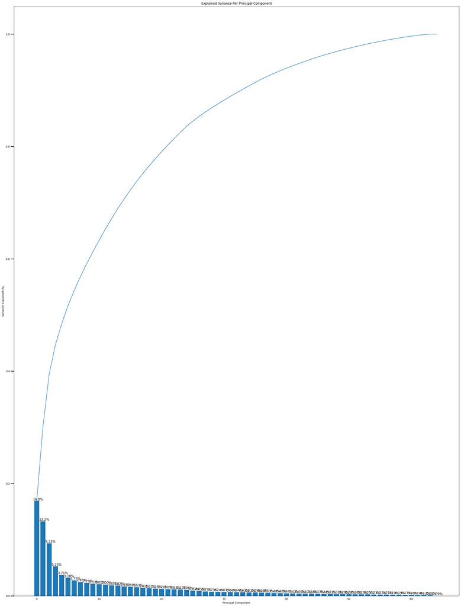

```python
# Apply PCA to the data for all the components.
pca, X_pca = do_pca(azdias_final.shape[1], azdias_final)

# Investigate the variance accounted for by each principal component.
scree_plot(pca)
```

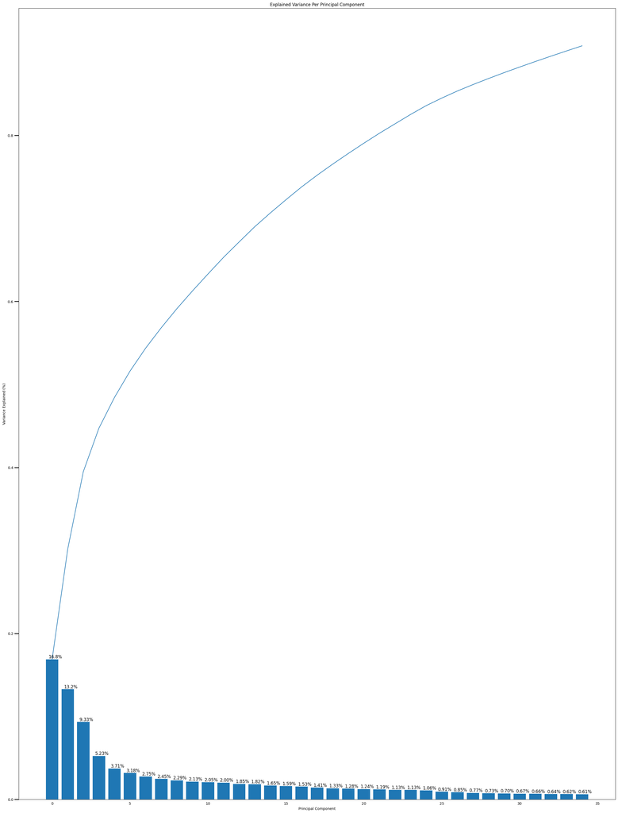

```python
# Re-apply PCA to the data to keep at least 90% of the variance
pca, X_pca = do_pca(35, azdias_final)

# Investigate the variance accounted for by each principal component.
scree_plot(pca)
```

### Discussion 2.2: Perform Dimensionality Reduction

The first six principal components account for over half (51.45%) of the variance in the dataset, of that the first two principal components account for 30% of the total variance in the dataset. I decided to keep 35 of the total 65 components since this will still account for 90% of the total variance for the data.

### Step 2.3: Interpret Principal Components

Now that we have our transformed principal components, it's a nice idea to check out the weight of each variable on the first few components to see if they can be interpreted in some fashion.

As a reminder, each principal component is a unit vector that points in the direction of highest variance (after accounting for the variance captured by earlier principal components). The further a weight is from zero, the more the principal component is in the direction of the corresponding feature. If two features have large weights of the same sign (both positive or both negative), then increases in one tend expect to be associated with increases in the other. To contrast, features with different signs can be expected to show a negative correlation: increases in one variable should result in a decrease in the other.

- To investigate the features, you should map each weight to their corresponding feature name, then sort the features according to weight. The most interesting features for each principal component, then, will be those at the beginning and end of the sorted list. Use the data dictionary document to help you understand these most prominent features, their relationships, and what a positive or negative value on the principal component might indicate.
- You should investigate and interpret feature associations from the first three principal components in this substep. To help facilitate this, you should write a function that you can call at any time to print the sorted list of feature weights, for the *i*-th principal component. This might come in handy in the next step of the project, when you interpret the tendencies of the discovered clusters.

```python
# Modified the pca_results function from the Udacity lessons to create dataframe of weights
def get_weights(data, pca):
	'''
	Create a DataFrame of the PCA results
	Includes dimension feature weights and explained variance
	'''

	# Dimension indexing
	dimensions = dimensions = ['pc_weight {}'.format(i) for i in range(1,len(pca.components_)+1)]

	# PCA components
	components = pd.DataFrame(np.round(pca.components_, 4), columns = data.keys())
	components.index = dimensions

	return components
```

```python
# Map weights for the first principal component to corresponding feature names
# and then print the linked values, sorted by weight.

mw = get_weights(azdias_final, pca)
print(mw.head(1).T.sort_values('pc_weight 1', ascending = False))
```

```
                                pc_weight 1
PLZ8_ANTG3                           0.2273
PLZ8_ANTG4                           0.2222
CAMEO_INTL_2015_WEALTH               0.2060
HH_EINKOMMEN_SCORE                   0.2010
ORTSGR_KLS9                          0.1995
EWDICHTE                             0.1975
FINANZ_HAUSBAUER                     0.1631
KBA05_ANTG4                          0.1574
PLZ8_ANTG2                           0.1535
ARBEIT                               0.1436
ANZ_HAUSHALTE_AKTIV                  0.1380
KBA05_ANTG3                          0.1362
RELAT_AB                             0.1356
FINANZ_SPARER                        0.1351
PRAEGENDE_JUGENDJAHRE_MOVEMENT       0.1066
SEMIO_PFLICHT                        0.1045
SEMIO_REL                            0.1018
PRAEGENDE_JUGENDJAHRE_DECADE         0.0891
SEMIO_RAT                            0.0856
SEMIO_TRADV                          0.0786
SEMIO_MAT                            0.0714
SEMIO_FAM                            0.0713
REGIOTYP                             0.0666
SEMIO_KULT                           0.0642
FINANZ_UNAUFFAELLIGER                0.0640
FINANZ_ANLEGER                       0.0592
PLZ8_HHZ                             0.0416
SEMIO_KAEM                           0.0414
SEMIO_SOZ                            0.0403
W_KEIT_KIND_HH                       0.0397
KKK                                  0.0366
ANZ_HH_TITEL                         0.0359
VERS_TYP                             0.0334
HEALTH_TYP                           0.0271
SEMIO_DOM                            0.0245
ANREDE_KZ                            0.0087
KBA05_ANTG2                          0.0083
SEMIO_KRIT                           0.0066
SOHO_KZ                             -0.0020
```

[output cut: 11 more lines]

```
FINANZ_VORSORGER                    -0.1038
GREEN_AVANTGARDE                    -0.1066
ALTERSKATEGORIE_GROB                -0.1077
GEBAEUDETYP_RASTER                  -0.1213
CAMEO_INTL_2015_LIFE_STAGE          -0.1247
BALLRAUM                            -0.1295
PLZ8_BAUMAX_FAMILY_HOME             -0.1484
INNENSTADT                          -0.1672
PLZ8_GBZ                            -0.1701
KONSUMNAEHE                         -0.1707
FINANZ_MINIMALIST                   -0.2128
KBA05_GBZ                           -0.2163
KBA05_ANTG1                         -0.2222
PLZ8_ANTG1                          -0.2283
MOBI_REGIO                          -0.2424
```

##### Dimension 1

Top 3 positive features:

- PLZ8_ANTG3: Number of 6-10 family houses in the PLZ8 region
- PLZ8_ANTG4: Number of 10+ family houses in the PLZ8 region
- CAMEO_INTL_2015_WEALTH: Wealth / Life Stage Typology, mapped to international code

Top 3 negative features:

- MOBI_REGIO: Movement patterns
- PLZ8_ANTG1: Number of 1-2 family houses in the PLZ8 region
- KBA05_ANTG1: Number of 1-2 family houses in the microcell

```python
# Map weights for the second principal component to corresponding feature names
# and then print the linked values, sorted by weight.

mw = get_weights(azdias_final, pca)
print(mw.head(2).T.sort_values('pc_weight 2', ascending = False).drop('pc_weight 1', axis=1))
```

```
                                pc_weight 2
ALTERSKATEGORIE_GROB                 0.2648
FINANZ_VORSORGER                     0.2373
SEMIO_ERL                            0.2328
SEMIO_LUST                           0.1869
RETOURTYP_BK_S                       0.1645
W_KEIT_KIND_HH                       0.1180
SEMIO_KRIT                           0.1142
FINANZ_HAUSBAUER                     0.1098
SEMIO_KAEM                           0.1093
ANREDE_KZ                            0.0888
EWDICHTE                             0.0823
ORTSGR_KLS9                          0.0809
PLZ8_ANTG3                           0.0807
PLZ8_ANTG4                           0.0776
FINANZ_MINIMALIST                    0.0762
SEMIO_DOM                            0.0689
KBA05_ANTG4                          0.0647
CAMEO_INTL_2015_WEALTH               0.0641
WOHNDAUER_2008                       0.0632
ARBEIT                               0.0601
RELAT_AB                             0.0579
ANZ_HAUSHALTE_AKTIV                  0.0569
PLZ8_ANTG2                           0.0553
HH_EINKOMMEN_SCORE                   0.0463
KBA05_ANTG3                          0.0394
VERS_TYP                             0.0305
ANZ_HH_TITEL                         0.0298
REGIOTYP                             0.0136
PRAEGENDE_JUGENDJAHRE_MOVEMENT       0.0101
PLZ8_HHZ                             0.0100
ANZ_TITEL                            0.0074
CAMEO_INTL_2015_LIFE_STAGE           0.0072
SOHO_KZ                             -0.0018
KKK                                 -0.0028
KBA05_ANTG2                         -0.0091
GREEN_AVANTGARDE                    -0.0101
OST_WEST_KZ                         -0.0233
KBA13_ANZAHL_PKW                    -0.0324
GEBAEUDETYP_RASTER                  -0.0397
```

[output cut: 11 more lines]

```
MOBI_REGIO                          -0.0764
PLZ8_ANTG1                          -0.0791
SEMIO_SOZ                           -0.1036
ONLINE_AFFINITAET                   -0.1629
SEMIO_MAT                           -0.1659
SEMIO_RAT                           -0.1746
SEMIO_FAM                           -0.1861
FINANZ_ANLEGER                      -0.2075
SEMIO_KULT                          -0.2214
FINANZ_UNAUFFAELLIGER               -0.2301
SEMIO_PFLICHT                       -0.2321
SEMIO_TRADV                         -0.2348
FINANZ_SPARER                       -0.2415
PRAEGENDE_JUGENDJAHRE_DECADE        -0.2559
SEMIO_REL                           -0.2581
```

##### Dimension 2

Top 3 positive features (Will increase/decrease in weight as the negative features below change):

- ALTERSKATEGORIE_GROB: Estimated age based on given name analysis
- FINANZ_VORSORGER: Financial typology: be prepared
- SEMIO_ERL: Personality typology: event-oriented

Top 3 negative features:

- SEMIO_REL: Personality typology: religious
- PRAEGENDE_JUGENDJAHRE_DECADE: Dominating movement of person's youth (decade)
- FINANZ_SPARER: Financial typology: money-saver

```python
# Map weights for the third principal component to corresponding feature names
# and then print the linked values, sorted by weight.

mw = get_weights(azdias_final, pca)
print(mw.head(3).T.sort_values('pc_weight 3', ascending = False).drop(['pc_weight 1', 'pc_weight 2'], axis=1))
```

```
                                pc_weight 3
SEMIO_VERT                           0.3456
SEMIO_SOZ                            0.2620
SEMIO_FAM                            0.2497
SEMIO_KULT                           0.2350
FINANZ_MINIMALIST                    0.1584
RETOURTYP_BK_S                       0.1079
FINANZ_VORSORGER                     0.1009
W_KEIT_KIND_HH                       0.0898
ALTERSKATEGORIE_GROB                 0.0790
SEMIO_REL                            0.0693
SEMIO_LUST                           0.0647
SEMIO_MAT                            0.0557
GREEN_AVANTGARDE                     0.0500
ORTSGR_KLS9                          0.0446
EWDICHTE                             0.0438
PLZ8_ANTG4                           0.0432
PLZ8_ANTG3                           0.0419
WOHNDAUER_2008                       0.0333
ARBEIT                               0.0325
RELAT_AB                             0.0296
PLZ8_ANTG2                           0.0273
KBA05_ANTG4                          0.0268
CAMEO_INTL_2015_WEALTH               0.0242
ANZ_HAUSHALTE_AKTIV                  0.0238
ANZ_HH_TITEL                         0.0132
ANZ_TITEL                            0.0099
KBA05_ANTG3                          0.0071
PLZ8_HHZ                             0.0034
VERS_TYP                             0.0018
SOHO_KZ                              0.0003
REGIOTYP                            -0.0073
ANZ_PERSONEN                        -0.0074
CAMEO_INTL_2015_LIFE_STAGE          -0.0076
KBA05_ANTG2                         -0.0110
OST_WEST_KZ                         -0.0149
MIN_GEBAEUDEJAHR                    -0.0167
KKK                                 -0.0173
KBA05_ANTG1                         -0.0186
HEALTH_TYP                          -0.0215
```

[output cut: 11 more lines]

```
FINANZ_HAUSBAUER                    -0.0447
PRAEGENDE_JUGENDJAHRE_MOVEMENT      -0.0500
ONLINE_AFFINITAET                   -0.0531
SEMIO_TRADV                         -0.0788
SEMIO_PFLICHT                       -0.0790
FINANZ_UNAUFFAELLIGER               -0.0993
PRAEGENDE_JUGENDJAHRE_DECADE        -0.1064
FINANZ_SPARER                       -0.1069
SEMIO_ERL                           -0.1763
FINANZ_ANLEGER                      -0.1894
SEMIO_RAT                           -0.2174
SEMIO_KRIT                          -0.2762
SEMIO_DOM                           -0.3142
SEMIO_KAEM                          -0.3374
ANREDE_KZ                           -0.3685
```

##### Dimension 3

Top 3 positive features (Will increase/decrease in weight as the negative features below change):

- SEMIO_VERT: Personality typology: dreamful
- SEMIO_SOZ: Personality typology: socially-minded
- SEMIO_FAM: Personality typology: family-minded

Top 3 negative features:

- ANREDE_KZ: Gender
- SEMIO_KAEM: Personality typology: combative attitude
- SEMIO_DOM: Personality typology: dominant-mindedFAM

### Discussion 2.3: Interpret Principal Components

For the first principal component it appears that the number of homes and the wealth of the indvidual have a high positive weight. Therefore, it makes sense that negative weights for the lower number of homes and the movement of an individual would contrast those top three positive features.

For the second principal component we can see that a person's age and financial personality are impacting this component with positive weight.

For the third principal component it appears that personality traits that are having a high positive weight include dreamful, socially-minded, and family-minded. The negative features in comparison makes sense because two of them are personality traits such as combative attitude and dominan-minded which are usually not associated with the other traits that are showing as positive.

From this we can also see that features representing wealth have the highest impact followed by someone's age and their financial personality, and finally we have the individual's personality also a large part of the variance that we saw when using the skee plot to look at variance earlier.

## Step 3: Clustering

### Step 3.1: Apply Clustering to General Population

You've assessed and cleaned the demographics data, then scaled and transformed them. Now, it's time to see how the data clusters in the principal components space. In this substep, you will apply k-means clustering to the dataset and use the average within-cluster distances from each point to their assigned cluster's centroid to decide on a number of clusters to keep.

- Use sklearn's KMeans class to perform k-means clustering on the PCA-transformed data.
- Then, compute the average difference from each point to its assigned cluster's center. **Hint**: The KMeans object's `.score()` method might be useful here, but note that in sklearn, scores tend to be defined so that larger is better. Try applying it to a small, toy dataset, or use an internet search to help your understanding.
- Perform the above two steps for a number of different cluster counts. You can then see how the average distance decreases with an increasing number of clusters. However, each additional cluster provides a smaller net benefit. Use this fact to select a final number of clusters in which to group the data. **Warning**: because of the large size of the dataset, it can take a long time for the algorithm to resolve. The more clusters to fit, the longer the algorithm will take. You should test for cluster counts through at least 10 clusters to get the full picture, but you shouldn't need to test for a number of clusters above about 30.
- Once you've selected a final number of clusters to use, re-fit a KMeans instance to perform the clustering operation. Make sure that you also obtain the cluster assignments for the general demographics data, since you'll be using them in the final Step 3.3.

```python
# Over a number of different cluster counts...
# run k-means clustering on the data and...
# compute the average within-cluster distance
scores = []
centers = list(range(1,21))

for center in centers:
    # Instantiate KMeans
    kmeans = KMeans(n_clusters=center)

    # Fit model to data
    model = kmeans.fit(X_pca)

    # Append score related to model to scores array
    scores.append(np.abs(model.score(X_pca)))

    print('Fitting center {}'.format(center))
```

```
Fitting center 1
Fitting center 2
Fitting center 3
Fitting center 4
Fitting center 5
Fitting center 6
Fitting center 7
Fitting center 8
Fitting center 9
Fitting center 10
Fitting center 11
Fitting center 12
Fitting center 13
Fitting center 14
Fitting center 15
Fitting center 16
Fitting center 17
Fitting center 18
Fitting center 19
Fitting center 20
```

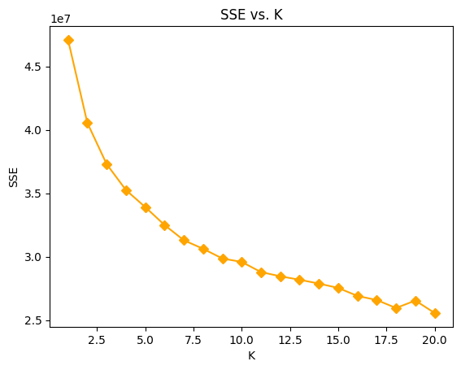

```python
# Investigate the change in within-cluster distance across number of clusters.
plt.plot(centers, scores, linestyle='-', marker='D', color='orange');
plt.xlabel('K');
plt.ylabel('SSE');
plt.title('SSE vs. K');
```

```python
# Re-fit the k-means model with the selected number of clusters and obtain
# cluster predictions for the general population demographics data.
kmeans_10 = KMeans(n_clusters=10, random_state=0)
model_10 = kmeans_10.fit(X_pca) #fit the model to your data using kmeans_10
azdiaz_gen_pop_clusters = model_10.predict(X_pca)
```

### Discussion 3.1: Apply Clustering to General Population

By viewing the SSE vs. K plot, I noticed that the elbow appears around 10 clusters for the biggest leveling out of the score. Therefore, I decided to use 10 clusters for my dataset.

### Step 3.2: Apply All Steps to the Customer Data

Now that you have clusters and cluster centers for the general population, it's time to see how the customer data maps on to those clusters. Take care to not confuse this for re-fitting all of the models to the customer data. Instead, you're going to use the fits from the general population to clean, transform, and cluster the customer data. In the last step of the project, you will interpret how the general population fits apply to the customer data.

- Don't forget when loading in the customers data, that it is semicolon (`;`) delimited.
- Apply the same feature wrangling, selection, and engineering steps to the customer demographics using the `clean_data()` function you created earlier. (You can assume that the customer demographics data has similar meaning behind missing data patterns as the general demographics data.)
- Use the sklearn objects from the general demographics data, and apply their transformations to the customers data. That is, you should not be using a `.fit()` or `.fit_transform()` method to re-fit the old objects, nor should you be creating new sklearn objects! Carry the data through the feature scaling, PCA, and clustering steps, obtaining cluster assignments for all of the data in the customer demographics data.

```python
# Load in the customer demographics data.
customers = pd.read_csv('Udacity_CUSTOMERS_Subset.csv', sep=';')
```

```python
# Apply preprocessing, feature transformation, and clustering from the general
# demographics onto the customer data, obtaining cluster predictions for the
# customer demographics data.
customers_clean = clean_data(customers)
```

```python
# Apply feature scaling to the customer demographics data.
customers_imp = pd.DataFrame(imp.transform(customers_clean), columns=customers_clean.columns)

customers_scaler = pd.DataFrame(scaler.transform(customers_imp), columns = customers_imp.columns)

cust_pca = pca.transform(customers_scaler)

cust_clusters = model_10.predict(cust_pca)
```

### Step 3.3: Compare Customer Data to Demographics Data

At this point, you have clustered data based on demographics of the general population of Germany, and seen how the customer data for a mail-order sales company maps onto those demographic clusters. In this final substep, you will compare the two cluster distributions to see where the strongest customer base for the company is.

Consider the proportion of persons in each cluster for the general population, and the proportions for the customers. If we think the company's customer base to be universal, then the cluster assignment proportions should be fairly similar between the two. If there are only particular segments of the population that are interested in the company's products, then we should see a mismatch from one to the other. If there is a higher proportion of persons in a cluster for the customer data compared to the general population (e.g. 5% of persons are assigned to a cluster for the general population, but 15% of the customer data is closest to that cluster's centroid) then that suggests the people in that cluster to be a target audience for the company. On the other hand, the proportion of the data in a cluster being larger in the general population than the customer data (e.g. only 2% of customers closest to a population centroid that captures 6% of the data) suggests that group of persons to be outside of the target demographics.

Take a look at the following points in this step:

- Compute the proportion of data points in each cluster for the general population and the customer data. Visualizations will be useful here: both for the individual dataset proportions, but also to visualize the ratios in cluster representation between groups. Seaborn's [`countplot()`](https://seaborn.pydata.org/generated/seaborn.countplot.html) or [`barplot()`](https://seaborn.pydata.org/generated/seaborn.barplot.html) function could be handy.
  - Recall the analysis you performed in step 1.1.3 of the project, where you separated out certain data points from the dataset if they had more than a specified threshold of missing values. If you found that this group was qualitatively different from the main bulk of the data, you should treat this as an additional data cluster in this analysis. Make sure that you account for the number of data points in this subset, for both the general population and customer datasets, when making your computations!
- Which cluster or clusters are overrepresented in the customer dataset compared to the general population? Select at least one such cluster and infer what kind of people might be represented by that cluster. Use the principal component interpretations from step 2.3 or look at additional components to help you make this inference. Alternatively, you can use the `.inverse_transform()` method of the PCA and StandardScaler objects to transform centroids back to the original data space and interpret the retrieved values directly.
- Perform a similar investigation for the underrepresented clusters. Which cluster or clusters are underrepresented in the customer dataset compared to the general population, and what kinds of people are typified by these clusters?

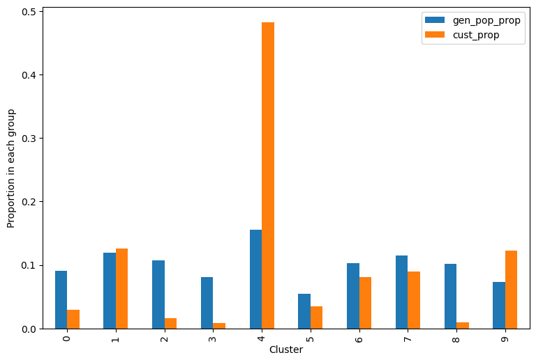

```python
# Compare the proportion of data in each cluster for the customer data to the
# proportion of data in each cluster for the general population.
gen_pop_prop = []
cust_prop = []
x = [i for i in range(10)]
for i in range(10):
    gen_pop_prop.append((azdiaz_gen_pop_clusters == i).sum()/len(azdiaz_gen_pop_clusters))
    cust_prop.append((cust_clusters == i).sum()/len(cust_clusters))


cluster_df = pd.DataFrame({'Cluster': x, 'gen_pop_prop': gen_pop_prop, 'cust_prop': cust_prop})

#ax = sns.countplot(x='index', y = df_general['prop_1', 'prop_2'], data=df_general )
cluster_df.plot(x= 'Cluster', y = ['gen_pop_prop', 'cust_prop'], kind='bar', figsize=(9,6))
plt.ylabel('Proportion in each group')
plt.show()
```

#### Which clusters are customers overrepresented in:

- cluster 1
- cluster 4 (will do an inspection into this cluster)
- cluster 9

#### Which clusters are customers underrepresented in:

- cluster 0
- cluster 2
- cluster 3
- cluster 5
- cluster 6
- cluster 7
- cluster 8 (will do an inspection into this cluster)

```python
extracted_data_cluster4 = scaler.inverse_transform(np.dot(cust_pca, pca.components_))[np.where(cust_clusters==4)]

extracted_data_cluster4 = pd.DataFrame(extracted_data_cluster_4, columns=azdias_final.columns)

extracted_data_cluster4.head()
```

|  | ALTERSKATEGORIE_GROB | ANREDE_KZ | FINANZ_MINIMALIST | FINANZ_SPARER | FINANZ_VORSORGER | FINANZ_ANLEGER | FINANZ_UNAUFFAELLIGER | FINANZ_HAUSBAUER | GREEN_AVANTGARDE | HEALTH_TYP | RETOURTYP_BK_S | SEMIO_SOZ | SEMIO_FAM | SEMIO_REL | SEMIO_MAT | SEMIO_VERT | SEMIO_LUST | SEMIO_ERL | SEMIO_KULT | SEMIO_RAT | SEMIO_KRIT | SEMIO_DOM | SEMIO_KAEM | SEMIO_PFLICHT | SEMIO_TRADV | SOHO_KZ | VERS_TYP | ANZ_PERSONEN | ANZ_TITEL | … |
| --- | --- | --- | --- | --- | --- | --- | --- | --- | --- | --- | --- | --- | --- | --- | --- | --- | --- | --- | --- | --- | --- | --- | --- | --- | --- | --- | --- | --- | --- | --- |
| 0 | 4.214480 | 0.873489 | 5.090334 | 0.974589 | 4.951487 | 0.779410 | 2.023030 | 2.420798 | 0.995722 | 1.009817 | 5.369270 | 5.721734 | 4.914010 | 2.918364 | 4.700726 | 7.500760 | 7.140731 | 4.235855 | 4.152904 | 1.466100 | 3.037909 | 1.586729 | 1.100806 | 1.548416 | 2.232283 | -0.000033 | 0.964643 | 2.013272 | 0.002366 | … |
| 1 | 3.550235 | 1.055208 | 5.156373 | 0.467984 | 5.187502 | 1.189500 | 1.027401 | 2.300136 | 0.007802 | 1.961750 | 3.016864 | 5.765886 | 4.930186 | 3.487504 | 4.091973 | 6.481990 | 4.814487 | 4.554300 | 5.194732 | 2.678919 | 3.643723 | 2.712408 | 2.364049 | 3.223911 | 3.160254 | -0.000192 | 0.939091 | 0.337123 | -0.002634 | … |
| 2 | 3.018986 | 1.090610 | 4.962166 | 0.883015 | 5.278688 | 0.691287 | 1.645020 | 2.567038 | 1.049709 | 3.003754 | 3.018316 | 6.456594 | 4.677264 | 3.423150 | 2.058264 | 5.762788 | 5.364220 | 3.927794 | 4.601336 | 2.339357 | 4.125513 | 4.270902 | 2.928702 | 3.511365 | 2.899939 | 0.000088 | 2.093729 | 1.943264 | -0.000023 | … |
| 3 | 3.278161 | 1.125073 | 5.403725 | 0.619069 | 5.440101 | 1.315416 | 1.212067 | 2.341885 | 0.970272 | 1.734807 | 5.059243 | 3.785596 | 3.899969 | 3.474149 | 1.607782 | 5.948268 | 4.673342 | 3.498434 | 4.534665 | 2.188877 | 2.381249 | 2.465599 | 2.068186 | 2.863189 | 2.561184 | -0.000006 | 1.026986 | 1.848933 | 0.001803 | … |
| 4 | 4.106284 | 0.885716 | 5.225375 | 0.921121 | 4.736897 | 0.559742 | 2.143491 | 2.369397 | 1.011793 | 1.023164 | 5.290378 | 5.588933 | 4.954661 | 3.150039 | 4.802668 | 7.443092 | 7.092052 | 4.182571 | 4.431642 | 1.677699 | 2.978139 | 2.059071 | 1.477022 | 1.825766 | 2.372930 | 0.000166 | 0.995026 | 2.112654 | 0.001990 | … |

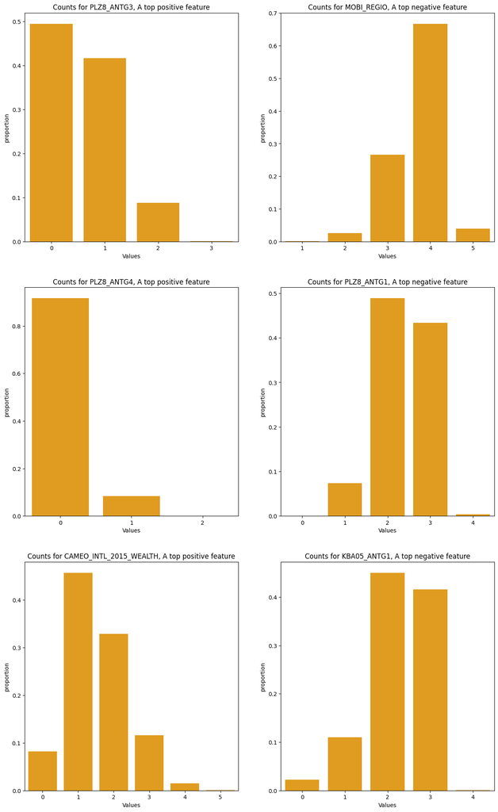

```python
fig, axes = plt.subplots(nrows = 3, ncols = 2, figsize = (15, 25))

sns.countplot(data=extracted_data_cluster4, x=extracted_data_cluster4.loc[:, 'PLZ8_ANTG3'].astype(int), ax = axes[0, 0], stat='proportion', color='orange');
axes[0, 0].set_title(f'Counts for PLZ8_ANTG3, A top positive feature');
axes[0, 0].set_xlabel('Values');

sns.countplot(data=extracted_data_cluster4, x=extracted_data_cluster4.loc[:, 'MOBI_REGIO'].astype(int), ax = axes[0, 1], stat='proportion', color='orange');
axes[0, 1].set_title(f'Counts for MOBI_REGIO, A top negative feature');
axes[0, 1].set_xlabel('Values');

sns.countplot(data=extracted_data_cluster4, x=extracted_data_cluster4.loc[:, 'PLZ8_ANTG4'].astype(int), ax = axes[1, 0], stat='proportion', color='orange');
axes[1, 0].set_title(f'Counts for PLZ8_ANTG4, A top positive feature');
axes[1, 0].set_xlabel('Values');

sns.countplot(data=extracted_data_cluster4, x=extracted_data_cluster4.loc[:, 'PLZ8_ANTG1'].astype(int), ax = axes[1, 1], stat='proportion', color='orange');
axes[1, 1].set_title(f'Counts for PLZ8_ANTG1, A top negative feature');
axes[1, 1].set_xlabel('Values');

sns.countplot(data=extracted_data_cluster4, x=extracted_data_cluster4.loc[:, 'CAMEO_INTL_2015_WEALTH'].astype(int), ax = axes[2, 0], stat='proportion', color='orange');
axes[2, 0].set_title(f'Counts for CAMEO_INTL_2015_WEALTH, A top positive feature')
axes[2, 0].set_xlabel('Values');

sns.countplot(data=extracted_data_cluster4, x=extracted_data_cluster4.loc[:, 'KBA05_ANTG1'].astype(int), ax = axes[2, 1], stat='proportion', color='orange');
axes[2, 1].set_title(f'Counts for KBA05_ANTG1, A top negative feature');
axes[2, 1].set_xlabel('Values');
```

#### What kinds of people are part of cluster 4 that is overrepresented in the customer data compared to the general population?

This is showing that these are wealthier customers mainly from the PLZ8 region that do not move around a lot.

##### PLZ8_ANTG4

Number of 10+ family houses in the PLZ8 region

- 0: no 10+ family homes

##### CAMEO_INTL_2015_WEALTH

German CAMEO: Wealth / Life Stage Typology, mapped to international code

- 1: Wealthy Households
- 2: Prosperous Households

```python
extracted_data_cluster8 = scaler.inverse_transform(np.dot(cust_pca, pca.components_))[np.where(cust_clusters==8)]

extracted_data_cluster8 = pd.DataFrame(extracted_data_cluster8, columns=azdias_final.columns)

extracted_data_cluster8.head()
```

|  | ALTERSKATEGORIE_GROB | ANREDE_KZ | FINANZ_MINIMALIST | FINANZ_SPARER | FINANZ_VORSORGER | FINANZ_ANLEGER | FINANZ_UNAUFFAELLIGER | FINANZ_HAUSBAUER | GREEN_AVANTGARDE | HEALTH_TYP | RETOURTYP_BK_S | SEMIO_SOZ | SEMIO_FAM | SEMIO_REL | SEMIO_MAT | SEMIO_VERT | SEMIO_LUST | SEMIO_ERL | SEMIO_KULT | SEMIO_RAT | SEMIO_KRIT | SEMIO_DOM | SEMIO_KAEM | SEMIO_PFLICHT | SEMIO_TRADV | SOHO_KZ | VERS_TYP | ANZ_PERSONEN | ANZ_TITEL | … |
| --- | --- | --- | --- | --- | --- | --- | --- | --- | --- | --- | --- | --- | --- | --- | --- | --- | --- | --- | --- | --- | --- | --- | --- | --- | --- | --- | --- | --- | --- | --- |
| 0 | 1.794824 | 2.133838 | 2.850440 | 2.626268 | 3.464305 | 2.295668 | 2.470341 | 2.086653 | -0.034015 | 1.912811 | 3.031677 | 5.157640 | 3.104243 | 4.243559 | 3.662459 | 2.358130 | 1.418890 | 4.675896 | 3.046374 | 5.979381 | 5.797470 | 6.816935 | 6.610867 | 6.139722 | 5.441513 | 0.000088 | 1.009875 | 0.910521 | -0.001775 | … |
| 1 | 3.200713 | 2.055396 | 0.976115 | 4.469993 | 1.863031 | 4.321400 | 4.236065 | 3.801280 | 0.005948 | 2.059652 | 1.090659 | 4.925137 | 2.748680 | 2.376676 | 4.168930 | 3.295702 | 6.332086 | 7.002263 | 2.383540 | 4.354356 | 4.184152 | 6.475833 | 6.817836 | 3.634107 | 3.576113 | 0.000132 | 0.985520 | 4.011434 | 0.001051 | … |
| 2 | 1.430712 | 1.929000 | 2.783615 | 1.285975 | 5.292832 | 1.212395 | 1.035272 | 4.609280 | -0.005262 | 3.074959 | 4.103792 | 5.012488 | 4.134171 | 5.450361 | 4.579593 | 2.064173 | 2.415368 | 3.971095 | 4.569712 | 6.469146 | 6.349173 | 6.991668 | 6.564932 | 6.936407 | 5.939928 | 0.000057 | 2.016250 | 0.923058 | -0.002830 | … |
| 3 | 1.953780 | 2.008402 | 0.875856 | 4.411411 | 2.041643 | 4.943959 | 2.909611 | 5.055082 | 0.038428 | 1.895202 | 4.903042 | 1.076455 | 4.160901 | 6.839610 | 3.911496 | 1.183152 | 7.119948 | 4.807783 | 4.522984 | 5.775668 | 4.719786 | 5.265579 | 5.994522 | 7.494886 | 4.338764 | 0.000091 | 1.985938 | 0.195736 | -0.002191 | … |
| 4 | 1.087540 | 1.896286 | 0.894408 | 4.645879 | 1.758946 | 5.364807 | 3.019914 | 5.114046 | -0.033842 | 2.966599 | 2.632973 | 4.367109 | 4.147988 | 5.843520 | 3.500650 | 2.026639 | 2.519101 | 3.069058 | 4.254996 | 5.709960 | 5.062792 | 5.718568 | 4.695037 | 6.620730 | 5.518302 | -0.000149 | 1.942833 | 1.279168 | -0.000162 | … |

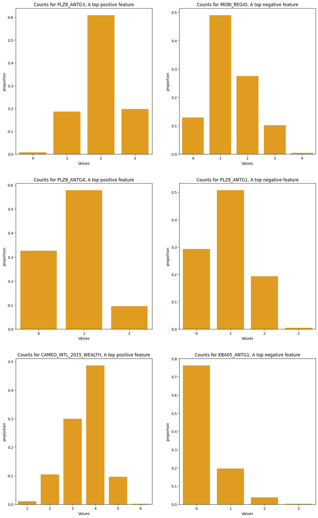

```python
fig, axes = plt.subplots(nrows = 3, ncols = 2, figsize = (15, 25))

sns.countplot(data=extracted_data_cluster8, x=extracted_data_cluster8.loc[:, 'PLZ8_ANTG3'].astype(int), ax = axes[0, 0], stat='proportion', color='orange');
axes[0, 0].set_title(f'Counts for PLZ8_ANTG3, A top positive feature');
axes[0, 0].set_xlabel('Values');

sns.countplot(data=extracted_data_cluster8, x=extracted_data_cluster8.loc[:, 'MOBI_REGIO'].astype(int), ax = axes[0, 1], stat='proportion', color='orange');
axes[0, 1].set_title(f'Counts for MOBI_REGIO, A top negative feature');
axes[0, 1].set_xlabel('Values');

sns.countplot(data=extracted_data_cluster8, x=extracted_data_cluster8.loc[:, 'PLZ8_ANTG4'].astype(int), ax = axes[1, 0], stat='proportion', color='orange');
axes[1, 0].set_title(f'Counts for PLZ8_ANTG4, A top positive feature');
axes[1, 0].set_xlabel('Values');

sns.countplot(data=extracted_data_cluster8, x=extracted_data_cluster8.loc[:, 'PLZ8_ANTG1'].astype(int), ax = axes[1, 1], stat='proportion', color='orange');
axes[1, 1].set_title(f'Counts for PLZ8_ANTG1, A top negative feature');
axes[1, 1].set_xlabel('Values');

sns.countplot(data=extracted_data_cluster8, x=extracted_data_cluster8.loc[:, 'CAMEO_INTL_2015_WEALTH'].astype(int), ax = axes[2, 0], stat='proportion', color='orange');
axes[2, 0].set_title(f'Counts for CAMEO_INTL_2015_WEALTH, A top positive feature')
axes[2, 0].set_xlabel('Values');

sns.countplot(data=extracted_data_cluster8, x=extracted_data_cluster8.loc[:, 'KBA05_ANTG1'].astype(int), ax = axes[2, 1], stat='proportion', color='orange');
axes[2, 1].set_title(f'Counts for KBA05_ANTG1, A top negative feature');
axes[2, 1].set_xlabel('Values');
```

#### What kinds of people are part of cluster 8 that is underrepresented in the customer data compared to the general population?

This is showing that these are less affluent households mainly from the PLZ8 region that move around a lot.

##### PLZ8_ANTG3

Number of 6-10 family houses in the PLZ8 region

- 2: average share of 6-10 family homes

##### PLZ8_ANTG4

Number of 10+ family houses in the PLZ8 region

- 1: lower share of 10+ family homes

##### CAMEO_INTL_2015

German CAMEO: Wealth / Life Stage Typology, mapped to international code

- 4: Less Affluent Households

##### MOBI_REGIO

Movement patterns

- 1: very high movement

##### PLZ8_ANTG1

Number of 1-2 family houses in the PLZ8 region

- 1: lower share of 1-2 family homes

##### KBA05_ANTG1

Number of 1-2 family houses in the microcell

- 0: no 1-2 family homes homes

### Discussion 3.3: Compare Customer Data to Demographics Data

Comparing data from cluster 4 and cluster 8 we can see that customer's are typically more wealthy than non-customers. Customer's typically do not move around a lot while non-customer's do tend to move around.

Based on these charastics the marketing team can better tailor marketing emails and digital ads to convert more customers and maintain a higher customer retention rate. This can also help the company to offer better products and potentially ensure closer delivery hubs to ensure faster delivery times since customers are not moving around as much.